# Investment and Trading Capstone Project: Build a Stock Price Indicator

This project consists of **two** main parts:

**1. build a stock predictor user interface**  
The stock predictor firstly asks the user to input: stocks we are interested in, a certain date range (training start date, training end date), a prediction interval (number of trading days), and a query date. Then it outputs the predicted future Adjusted Close prices of the stocks for the user. The framework of the interface is as follows.

- The interface firstly asks users to input a training start date, a training end date and a list of stock symbols (e.g. GOOG, AAPL). The interface will ask users to choose a positive integer from 1, 5, 10 and 20. The integer indicates the prediction interval in terms of trading days. For example, choosing prediction interval 5 means that the user want the interface to predict the Adjusted Closes price of the day that is 5 trading days after the query date.
- According to the input, the daily trading data of the stocks and S&P 500 ranging from the training start date to the training end date are extracted directly from the Yahoo! Finance by the API of python module **pandas_datareader.data**. Since the project is to predict Adjusted Close prices, we extract the Adjusted Close prices from the raw data. These works can be done by the function **get_data()** described in section 1.1.
- Some technical indicators such as Bollinger Bond Value, Relative Strengh Index and so on are computed based on the Adjusted Close data. For each stock of interest, 18 technical indicators are computed, and they will be used as input features in our regression models. The target value of our regression models is the rate (in percentage) that the price will change at the future date corresponds to the prediction interval. The target value is also computed based on the Adjusted Close data. The features and corresponding target value are combined to form the training data. These works can by done by the function **process_data()** function in section 1.1. Both **get_data()** and **process_data()** functions are included in file **DataGetter.py**.
- Regression methods including KNN, Bagging, Decision Tree and Random Forest are applied on the training data. Decision Tree and Random Forest methods are from the **sci-kit learn** module. KNN and Bagging methods are implemented by myself. They are described in section 1.2. During the model fitting process, each method attempts different choices of tuning parameters. All the models are evaluated in the training phase, and the best model is selected as the final model of the predictor interface. Specifically, we firstly divide the training data into two parts: a smaller training data set (75%) and a validation data set (25%). Then the smaller training data set is used to fit regression models, each of which attempts different tuning paramters. These models' performance then are evaluated on the validation data set, and the best method and corresponding optimal choice of the tuning parameter are selected. Finally, we use the whole training data set to fit a regression model using the best method and its corresponding optimal choice of tuning parameter. And this model will be used as the final model in the predictor system. These works are done by the methods of **BestLearner** class.
- After the final model is obtained, the user interface will ask the user to input a query date. The features at the query date will be computed and used to predict the rate of change of the stocks. Then the predictions of each stock's future price is computed based on its price at the query date and its predicted rate of change. The interface then output the predictions.

All the above works are combined in the class **StockIndicator**, which is included in the file **StockIndicator.py**. The code for the user interface consists of DataGetter.py, KNN.py, BagLearner.py, BestLearner.py and StockIndicator.py. The interface can be run under Ubuntu 14.04 by typing "python StockIndicator.py" in the terminal. The interface can also be run in this notebook. The details will be illustrated in the section 1.

**2. case studies based on the stock predictor**  
Three case studies are conducted to evaluate the stock predictor we built in part 1. They are:

- **Google**: training date range: 01/01/2011-12/31/2014, testing date range: 01/01/2015-12/31/2015
- **Apple**: training date range: 01/01/2003-12/31/2007, testing date range: 01/01/2008-12/31/2008
- **IBM**: training date range: 01/01/2010-12/31/2013, testing date range: 01/01/2014-12/31/2014

In each case study, a stock predictor is built using the data of training date range. Then the predictor is tested on the data of testing date range. The mean absolute percentage error (MAPE) is used as the metrics to evaluate the performance of the predictor. We also construct a trading strategy based on the predictions given by the predictor. The trading strategy is then used to trade the stock on the testing date range, and the portfolio values are computed. To evaluate the trading strategy, the cumulative return and Sharpe ratio on the portfolio values will be computed. Also, we will use the stock prices during the testing date range as the benchmark to compare with the portfolio values. These works are all implemented in the class **TradeStock**. The trading strategy is implemented in the method **create_orders()**. The method **create_results()** generates the results of the study.

The code for case studies is included in file **TradingStrategy.py**. By typing "python TradingStrategy.py" in the terminal, the results of the studies shown in the report will be generated. The explanation of the code will be illustrated in the later part of this notebook. Also, the results and plots that shown in the report will also be generated and explained in the notebook.

First of all, import the modules that are needed for this project. The modules are as follows.

```python
import numpy as np
import pandas as pd
import pandas_datareader.data as web #API for extract daily trading data from Yahoo! Finance
import datetime as dt
from sklearn.tree import DecisionTreeRegressor
from sklearn.ensemble import RandomForestRegressor
import matplotlib.pyplot as plt
%matplotlib inline
```

## 1. Build a stock predictor user interface

### 1.1 Extract Stock Price Data and Pre-process Data

**get_data()** and **process_data()** functions are included in **DataGetter.py** file.

The function **get_data()** takes stock symbols (symbols) and a training start date (train_sd) as input arguments. Then the function extracts daily Adujusted Close price data of the stocks and S&P 500 from Yahoo! Finance. The extracted price data are ranging from the training start date (train_sd) to present day. The function returns the extracted data as a dataframe.

The data are extracted from Yahoo Finance through the API **pandas_datareader.data**, which has been imported as **web** at the beginning of the notebook.

Also, the output data frame not only includes the price of the input stocks, but also includes the price of the S&P 500, which has the column name "SPY" in the output data frame. The reason for including the "SPY" price is tha we also want the technical indicators generated from "SPY" price to be the input features of our regression models.

The detail of the **get_data()** function is shown as follows:

```python
def get_data(symbols, train_sd, data_source = "yahoo"):

    """
    The function takes some stock symbols and a training start date as input,
        and extracts close prices data of these symbols and SPY from yahoo finance,
        ranging from the specified training start date to present day.

    @param symbols:  a list, symbols to extract from yahoo finance
    @param train_sd: a datetime object, training data start date
    @return:         a dataframe containing adjusted close prices of the symbols
                     and SPY from train_sd to present
    """

    if "SPY" not in symbols:
        symbols = symbols + ["SPY"]

    df = web.DataReader(name=symbols[0], data_source=data_source, start=train_sd)[["Adj Close"]]
    #use double [[]] returns a DataFrame, not a Series
    df = df.rename(columns={"Adj Close": symbols[0]})

    for i in range(1, len(symbols)):
        df_temp = web.DataReader(name=symbols[i], data_source=data_source, start=train_sd)[["Adj Close"]]
        df_temp = df_temp.rename(columns={"Adj Close": symbols[i]})
        df = df.join(df_temp)

    df = df.dropna(subset=["SPY"])

    return df
```

The **process_data()** function computes technical indicators based on the daily Adjusted Close prices obtained by get_data() function, and the rate of future change of the stock corresponds to the input prediction interval. The technical indicators and the rate of change are then combined to a dataframe. The dataframe is then divided to two parts by the input training end date. The two dataframes are then returned.

The input arguments of the the function include a dataframe (**df_allprices**) containing Ajusted Close prices of stocks and S&P 500, a stock symbol (**symbol**), the training end date (**train_ed**), and the prediction interval (**n_days**). The function will extract the stock price of the input stock (**symbol**) from the input dataframe (**df_allprices**), and then generate 18 technical indicators which will be used as features in regression models. The technical indicators include:

1. Billinger Bonds values for 5, 10 and 20 trading days of the stock price respectively
2. Billinger Bonds values for 5, 10 and 20 trading days of the S&P 500 respectively
3. Rate of Change of the stock's price for the past 5, 10 and 20 trading days respectively
4. Rate of Change of S&P 500 for the past 5, 10 and 20 trading days respectively
5. RSI values for 5, 10 and 20 trading days of the stock price respectively
6. RSI values for 5, 10 and 20 trading days of the SP&P 500

The function also compute the rate of future change of the stock corresponds to the input prediction interval (**n_days**). For example, if we input n_days=5, then the rate of changes of the stock price 5 trading days later will be computed. The rate of change will be used as target variable in the regression models. Besides, the stock price and the future actual stock price are also included in the output data frames for the use of model evaluations in the future case studies.

The function returns two data frames: training data frame and testing data frame. Both data frames contain technical indicators of the input symbol and SPY as columns. Also, the rate of change, stock price and future actual stock price are included in the data frames as columns. The training data frame have the date range from the training start date to the training end date. The testing data frame has the date range from the day after the training end date to present day.

The code of the funcion is:

```python
def process_data(df_allprices, symbol, train_ed, n_days):
    """
    The function computes technical indicators based on the prices data obtained by get_data() function,
        and returns training set and testing set of a specified symbol.
    The returned training and testing set are dataframes that contain technical indicators as columns.
    The returned dataframes also contains rate of change as target variable, stock prices and future actual stock prices.
    The indicators contains: Billinger Bonds values for 5, 10 and 20 trading days of the symbol's prices
                             Billinger Bonds values for 5, 10 and 20 trading days of the SPY prices
                             Rate of Change values for the past 5, 10 and 20 trading days of the symbol's prices
                             Rate of Change values for the past 5, 10 and 20 trading days of the SPY prices
                             RSI values for 5, 10 and 20 trading days of the symbol's prices
                             RSI values for 5, 10 and 20 trading days of the SPY prices
    The input n_days denotes the prediction interval,
        e.g. n_days=5 means you want to predict the stock price at the day that is 5 trading days later.

    @param df_allprices: dataframe, adj close of all symbols and SPY
    @param symbol:       str, the symbol to process
    @param train_ed:     datetime object, training end date
    @param n_days:       int, prediction interval, e.g. n_days=5 means you want to
                         predict the stock price 5 trading days later.
    return: two dataframes with stock indicators of symbol and SPY
            Dataframes also contains rate of change as target variable (Y).
            Dataframes also contains stock prices and future stock prices.
            Two dataframs are training and testing sets respectively.
    """

    ans_df = pd.DataFrame(index=df_allprices.index) #initialize the output data frame
    df_symbol = df_allprices[symbol] #extract the stock price of the input symbol from df_allprices
    df_SPY = df_allprices["SPY"] #extract the SPY price from df_allprices

    #compute Billinger Bond values for 5 trading days of the symbol's stock price
    sma_5 = pd.Series.rolling(df_symbol, window=5, center=False).mean()
    std_5 = pd.Series.rolling(df_symbol, window=5, center=False).std()
    bb_5 = (df_symbol - sma_5) / (2 * std_5)
    ans_df["BB_5"] = bb_5

    #compute Billinger Bond values for 10 trading days of the symbol's stock price
    sma_10 = pd.Series.rolling(df_symbol, window=10, center=False).mean()
    std_10 = pd.Series.rolling(df_symbol, window=10, center=False).std()
    bb_10 = (df_symbol - sma_10) / (2 * std_10)
    ans_df["BB_10"] = bb_10

    #compute Billinger Bond values for 20 trading days of the symbol's stock price
    sma_20 = pd.Series.rolling(df_symbol, window=20, center=False).mean()
    std_20 = pd.Series.rolling(df_symbol, window=20, center=False).std()
    bb_20 = (df_symbol - sma_20) / (2 * std_20)
    ans_df["BB_20"] = bb_20

    #compute Billinger Bond values for 5 trading days of SPY price
    sma_5_SPY = pd.Series.rolling(df_SPY, window=5, center=False).mean()
    std_5_SPY = pd.Series.rolling(df_SPY, window=5, center=False).std()
    bb_5_SPY = (df_SPY - sma_5_SPY) / (2 * std_5_SPY)
    ans_df["BB_5_SPY"] = bb_5_SPY

    #compute Billinger Bond values for 10 trading days of SPY price
    sma_10_SPY= pd.Series.rolling(df_SPY, window=10, center=False).mean()
    std_10_SPY = pd.Series.rolling(df_SPY, window=10, center=False).std()
    bb_10_SPY = (df_SPY - sma_10_SPY) / (2 * std_10_SPY)
    ans_df["BB_10_SPY"] = bb_10_SPY

    #compute Billinger Bond values for 20 trading days of SPY price
    sma_20_SPY= pd.Series.rolling(df_SPY, window=20, center=False).mean()
    std_20_SPY = pd.Series.rolling(df_SPY, window=20, center=False).std()
    bb_20_SPY = (df_SPY - sma_20_SPY) / (2 * std_20_SPY)
    ans_df["BB_20_SPY"] = bb_20_SPY

    # compute rate of change in stock price of the symbol for the past 5 trading days
    roc_5 = df_symbol[5:]/df_symbol[:-5].values - 1
    ans_df["ROC_5"] = roc_5

    # compute rate of change in stock price of the symbol for the past 10 trading days
    roc_10 = df_symbol[10:]/df_symbol[:-10].values - 1
    ans_df["ROC_10"] = roc_10

    # compute rate of change in stock price of the symbol for the past 20 trading days
    roc_20 = df_symbol[20:]/df_symbol[:-20].values - 1
    ans_df["ROC_20"] = roc_20

    # compute rate of change in SPY price for the past 5 trading days
    roc_5_SPY = df_SPY[5:]/df_SPY[:-5].values - 1
    ans_df["ROC_5_SPY"] = roc_5_SPY

    # compute rate of change in SPY price for the past 10 traing days
    roc_10_SPY = df_SPY[10:]/df_SPY[:-10].values - 1
    ans_df["ROC_10_SPY"] = roc_10_SPY

    # compute rate of change in SPY price for the past 20 trading days
    roc_20_SPY = df_SPY[20:]/df_SPY[:-20].values - 1
    ans_df["ROC_20_SPY"] = roc_20_SPY

    # compute RSI indicator of symbol's price
    delta = df_symbol.diff()
    up, down = delta.copy(), delta.copy()
    up[up < 0] = 0
    down[down > 0] = 0

    # RSI of the symbol's price for 5 trading days
    up_5 = pd.Series.rolling(up, window=5, center=False).mean()
    down_5 = pd.Series.rolling(down.abs(), window=5, center=False).mean()
    RS_5 = up_5 / down_5
    RSI_5 = 100.0 - (100.0 / (1.0 + RS_5))
    ans_df["RSI_5"] = RSI_5

    # RSI of the symbol's price for 10 trading days
    up_10 = pd.Series.rolling(up, window=10, center=False).mean()
    down_10 = pd.Series.rolling(down.abs(), window=10, center=False).mean()
    RS_10 = up_10 / down_10
    RSI_10 = 100.0 - (100.0 / (1.0 + RS_10))
    ans_df["RSI_10"] = RSI_10

    # RSI of the symbol's price for 20 trading days
    up_20 = pd.Series.rolling(up, window=20, center=False).mean()
    down_20 = pd.Series.rolling(down.abs(), window=20, center=False).mean()
    RS_20 = up_20 / down_20
    RSI_20 = 100.0 - (100.0 / (1.0 + RS_20))
    ans_df["RSI_20"] = RSI_20

    # compute RSI of SPY
    delta_SPY = df_SPY.diff()
    up_SPY, down_SPY = delta_SPY.copy(), delta_SPY.copy()
    up_SPY[up_SPY < 0] = 0
    down_SPY[down_SPY > 0] = 0

    # compute RSI of SPY for 5 days
    up_5_SPY = pd.Series.rolling(up_SPY, window=5, center=False).mean()
    down_5_SPY = pd.Series.rolling(down_SPY.abs(), window=5, center=False).mean()
    RS_5_SPY = up_5_SPY / down_5_SPY
    RSI_5_SPY = 100.0 - (100.0 / (1.0 + RS_5_SPY))
    ans_df["RSI_5_SPY"] = RSI_5_SPY

    # compute RSI of SPY for 10 days
    up_10_SPY = pd.Series.rolling(up_SPY, window=10, center=False).mean()
    down_10_SPY = pd.Series.rolling(down_SPY.abs(), window=10, center=False).mean()
    RS_10_SPY = up_10_SPY / down_10_SPY
    RSI_10_SPY = 100.0 - (100.0 / (1.0 + RS_10_SPY))
    ans_df["RSI_10_SPY"] = RSI_10_SPY

    # compute RSI of SPY for 20 days
    up_20_SPY = pd.Series.rolling(up_SPY, window=20, center=False).mean()
    down_20_SPY = pd.Series.rolling(down_SPY.abs(), window=20, center=False).mean()
    RS_20_SPY = up_20_SPY / down_20_SPY
    RSI_20_SPY = 100.0 - (100.0 / (1.0 + RS_20_SPY))
    ans_df["RSI_20_SPY"] = RSI_20_SPY

    # add target variable Y (rate of change) to the output data frame ans_df
    y = df_symbol[n_days:].values/df_symbol[:-n_days] - 1
    ans_df["Y"] = y

    # add the price and the future price of the symbol to the output data frame ans_df
    ans_df["price"] = df_symbol
    ans_df["future_price"] = np.concatenate((df_symbol[n_days:].values, [np.nan]*n_days))

    #split ans_df into train_df and test_df by the training end date train_ed
    train_df = ans_df[:train_ed]
    test_df = ans_df[train_ed+dt.timedelta(days=1):]
    train_df = train_df.dropna() #drop na from the training set

    return train_df, test_df
```

### 1.2 Regression models

In this section, we will illustrate the implementations of regression models we use in this project. The regression models include KNN, Bagging, Decision Tree and Random Forest. The Decision Tree and Random Forest methods use classes provided by **sci-kit learn** model. They are already imported at the beginning of the notebook. The KNN and Bagging methods are implemented by myself as sci-kit learn style classes. Besides the models, a class called **BestLearner** that provides methods of evaluating models and selecting best model in the training phase is implemented.

In this project, the features of regression models are 18 technical indicators, and the target value is the rate in percentage the stock will change. Remember that our task of stock price predictor is to predict the stock price, not the rate of change. After we predict the rate of change, the future stock price can by easily computed by multiplying the price at the query date with (1 + predicted rate of change).

The implementations of these models are shown as follows.

#### 1.2.1 K-Nearest- Neighbors Regression Model

The class **KNNLearner** is included in **KNN.py**. The modules **numpy** and **pandas** need to be imported before the class is built.

The class **KNNLearner** builds a KNN regression model object and provides a method to make prediction on new input instances. The default **k** is 3, and you can adjust **k** to any value you want in the class initialization step. The methods in the class is sci-kit learner style. The detailed code is as follows:

```python
class KNNLearner(object):
    """
    The class builds a KNN regression model object and provides a method
        to make prediction on new input points.

    """

    def __init__(self, k=3, verbose=False):
        #initialize the k in KNN model.
        self.k = k

    def fit(self, dataX, dataY):
        """
        This method stores the training X and Y respectively for the
            use of the future prediction.

        @param dataX: 2-d array
        @param dataY: Series
        """
        self.X = dataX
        self.Y = dataY


    def predict(self, points):
        """
        The method takes a 2-d array as input and return a 1-d array
            as the prediction based on the KNN algorithm.

        @param points: must be 2d -array, if not reshape it
        @return: 1d-array, predicted values
        """

        #reshape points to 2-d array if points is 1-d array
        if len(points.shape) == 1:
            points = points.reshape(1, -1)

        ans = np.array([])
        for i in range(points.shape[0]):
            xi = points[i]
            dists = np.sqrt(((self.X - xi) ** 2).sum(axis=1)) #find distances
            idxes = dists.argsort()[:self.k] #sort distances and get the first kth
            pred_y = self.Y[idxes].mean() #compute the mean of the k values as the prediction
            ans = np.append(ans, [pred_y])
        return ans
```

#### 1.2.2 Bagging for KNN model

The **BagLearner** class builds a bagging ensemble model. The default base regression model in the ensemble is the KNN model that was described in the above. Each base model is fitted on a bootstrapped data set. The default ensemble size 20, and it can be adjusted during the class initialization. The class is also a sci-kit learn style, which provides **fit()** and **predict()** methods. The details of the class is shown in below code.

```python
class BagLearner(object):
    """
    The class builds a bagging ensemble model that contains many base regression models.
    The base regression models in the bagging ensemble is KNN model.
    Each model is built based on the data set bootstraped from the training data.
    The default number of KNN models in the bag is 20, and it can be changed
        during the initialization.
    The class also provides a method to make predictions on new inputs.
    """

    def __init__(self, learner=KNNLearner, kwargs={"k":3}, n_learners=20, random_state=817):
        """
        @param leaner: base leaner class, defaulst is the KNN model
        @param n_leaners: int, number of base leaners in the bag, default is 20

        self.leaners: list, store leaners
        """
        self.random_state = random_state
        self.learners = []
        self.n_learners = n_learners

        #initialize the base KNN regression models in bagging ensemble
        for i in range(self.n_learners):
            self.learners.append(learner(**kwargs))


    def fit(self, dataX, dataY):
        """
        For each leaner in the bag, the function bootstraps
           the training data and fit the model.

        @param dataX: 2d-array
        @param dataY: Series
        """
        n = dataX.shape[0]
        # n is the number of training instances

        #set seed for reproduce result
        np.random.seed(self.random_state)

        for i in range(self.n_learners):
            #bootstrap n indices
            idxes = np.random.choice(n, n)

            X = dataX[idxes] #bootstrap training X
            Y = dataY[idxes] #bootstrap training Y
            self.learners[i].fit(X, Y) #train each KNN base model.

    def predict(self, points):
        """
        @param points: ndarray
        @return: 1-d array
        """
        ans = self.learners[0].predict(points)
        # ans is a 1-d array

        for i in range(1, self.n_learners):
            ans += self.learners[i].predict(points)

        #average the predictions of learners in the bag
        ans = ans / self.n_learners
        return ans
```

#### 1.2.3 Best regression model

The **BestLearner** class provides methods that evaluate models of KNN, Bagging, Decision Tree and Random Forest based on the performance of validation data set, and select the best one as the final regression model of the predictor system. It is included in **BestLearner.py**.

The class object of the **BestLearner** class is initialized by inputing a dataframe of training data obtained from the function **process_data()**. The input training dataframe contains technical indicators and rate of change as target variable (Y) and stock prices and future actual prices of the stock. In the **init()** method, the input training data set is firstly divided into two parts: a smaller training set and a validation set. The smaller training set is the first 75% of the input training data set, and the validation data set is the remaining 25% of the input training data set. Then the input training data set, the smaller training data set and the validation data set are normalized respectively.

Then we build regression models based on the smaller training set using KNN, BagLearner, Regression Tree and Random Forest methods, each of which attempts different choices of tuning paramters.

The method **bestBagLearner()** firstly builds 9 Bagging models that uses 20, 30, ..., 100 as the size of the ensemble (**n_learners**) respectively on the normalized smaller training data set. The base model in the Bagging is the KNN learner. The **k** we use in each KNN learner is the optimal **k** returned from the **bestKNN** method. For each of the 9 Bagging models, the MAPE on the validation data set is computed. The best Bagging model is then selected as the one that has the minimum MAPE value. The method returns the size (**optimal_n**) of the best Bagging model and its corresponding MAPE. This method uses the **BagLearner** class that has been implemented above.

The method **bestTree()** firstly builds 6 regreesion tree models that have different complexities. The method uses the **DecisionTreeRegressor()** method from sci-kit learn module to fit each tree model. The complexity of each tree is controlled by the argument **min_samples_split** of the **DecisionTreeRegressor()** method. The values 5, 10, 15, 20, 25 and 30 will be attempted to the argument **min_samples_split** respectively. All the 6 tree models are built based on the normalized smaller training data set. Then, the MAPEs of theses 6 models on the validation data set are computed. The method selects the tree model that has the minimum MAPE value as the best tree model. The method then returns the **min_samples_split** of the best tree model (**optimal_min_samples_split**) and its corresponding MAPE.

The method **bestForest()** firstly builds 9 Random Forest models which have the size of the ensemble 20, 30, 40,..., 100 respectively. Each random forest model is built using the **RandomForestRegressor()** function from sci-kit learn module. The size of each random forest is controlled by the argument **n_estimators** in **RandomForestRegressor()** function. Each random forest is built based on the smaller training set. Then, the MAPEs of the random forests are computed on the validation set. The method selects the Random Forest that has the minimum MAPE as the best Random Forest among these 9 models. Then the method returns the ensemble size (**optimal_n_trees**) of the best Random Forest and the corresponding MAPE.

The detailed code of the clss **BestLearner()** is given as follows.

```python
class BestLearner(object):
    """
    The class object is initialized by inputing a training dataframe.
    The input dataframe contains stock indicators and rate of change as target variable
        and stock prices and future actual prices of a specific symbol.
    The training set is divided into a smaller training set and a validation set.
    Several models are built based on the smaller training set.
    The models are KNN, BagLearner, Regression Tree and Random Forest.
    These models are built using different tunning parameters.
    These models are evaluated based on the validation set and the optimal model with
        the optimal tunning parameters is obtained.
    The model evaluation metrics used is the mean absolute percentage error (mape) on
        the validation set.
    Using the optimal tunning parameters, the optimal model is built again based on the
        whole training set (combine small training set and validation set).
    This final optimal model is used for the future prediction.
    """

    def __init__(self, df_train):
        """
        @param df_train: processed dataframe of a specific symbol
                        It contains stock indicators and
                        rate of change as target variable and
                        stock prices and future actual prices.
        @initialization:
        self.df_train: processed dataframe, df_train, including xs and y and prices

        self.mean:          columns means, for normalization
        self.std:           columns std, for normalization
        self.trainX_normed: 2-d array, normalized training x
        self.trainY:        Series, training y

        self.small_trainX_normed: 2-d array, normalized small training x
        self.small_trainY:        Series, small training y

        self.validationX_normed:     2-d array, normalized validation x
        self.validationPrices:       prices of the symbol in validation set
        self.validationFuturePrices: future actual prices of the symbol in the validation set
        """
        self.df_train = df_train
        trainX = self.df_train[self.df_train.columns[:-3]].values
        self.mean = trainX.mean(axis = 0)
        self.std = trainX.std(axis = 0)
        self.trainX_normed = (trainX - self.mean) / self.std
        self.trainY = self.df_train["Y"]

        n = trainX.shape[0]
        small_train_size = int(n * 0.75)

        small_trainX = trainX[:small_train_size]
        small_mean = small_trainX.mean(axis = 0)
        small_std = small_trainX.std(axis = 0)
        self.small_trainX_normed = (small_trainX - small_mean) / small_std
        #self.small_trainX is a ndarray

        self.small_trainY = self.trainY[:small_train_size]
        #self.small_trainY is a Series

        validationX = trainX[small_train_size:]
        self.validationX_normed = (validationX - small_mean) / small_std
        #self.validationX is a ndarray

        self.validationPrices = self.df_train["price"][small_train_size:]
        #self.validationPrices is a Series

        self.validationFuturePrices = self.df_train["future_price"][small_train_size:]
        #self.validationFuturePrices is a Series

    def bestKNN(self):
        """
        The method builds several KNN learners with different k based on small training set.
        Then these learners are evaluated based on the validation set.
        The optimal learner with optimal k then is selected.

        @return: optimal int k, which denotes the optimal k of the optimal KNN learner
                 that give the best performance on validation set,
                 and the corresponding mean absolute percentage error (mape)

        The performance metrics is the mean absolute percentage error (mape)
        between predicted future prices and actual future prices of validation set.

        The choices of k are integers ranging from 3 to 20.
        """
        optimal_mape = 1
        optimal_k = 3

        for k in range(3, 20):
            knn = KNNLearner(k = k)
            knn.fit(self.small_trainX_normed, self.small_trainY) #fit a KNN model
            predicted_roc = knn.predict(self.validationX_normed) #predict the rate of change
            predicted_prices = self.validationPrices * (1 + predicted_roc) #compute the predicted prices
            mape = np.mean(np.abs(predicted_prices - self.validationFuturePrices) / self.validationFuturePrices)
            #compute MAPE on validation set

            #find the minimum MAPE and corresponding optimal k
            if mape < optimal_mape:
                optimal_mape = mape
                optimal_k = k

        return optimal_k, optimal_mape

    def bestBagLearner(self):
        """
        The method builds several BagLearner models based on small training set.
        The base model in the BagLearner is the KNN learner.
        The k in KNN learner is obtained by the method self.bestKNN()
        These BagLearner models have different n_learners parameter, which denotes number
        of base learners in the bag.
        The optimal model with the optimal n_learners will be obtained based on validation set.

        @return: optimal integer n_learners, which denotes the number of learners in the bag

        The choices of n_learners are 20, 30, 40, ..., 100
        """
        k = self.bestKNN()[0] # compute the optimal k by bestKNN() method
        #k will be used for constructing base model in the bagging ensemble

        optimal_n = 20
        optimal_mape = 1

        #try different bagging models with different ensemble size
        for n_learners  in range(20, 101, 10):
            bag = BagLearner(learner=KNNLearner, kwargs={"k":k}, n_learners=n_learners) #bagging model
            bag.fit(self.small_trainX_normed, self.small_trainY)
            predicted_roc = bag.predict(self.validationX_normed) #predict rate of change on validation set
            predicted_prices = self.validationPrices * (1 + predicted_roc)#compute predicted prices on validation set
```

```python
            #compute MAPE on validation set
            mape = np.mean(np.abs(predicted_prices - self.validationFuturePrices) / self.validationFuturePrices)

            #update the minimum MAPE and corresponding optimal ensemble size
            if mape < optimal_mape:
                optimal_mape = mape
                optimal_n = n_learners

        return optimal_n, optimal_mape

    def bestTree(self):
        """
        The method builds a set of regression tree models with different tunning paramters
            based on the small training set.
        The tunning parameter used is the min_samples_split, which is a parameter for controling
            the complexity of the tree.
        The values of min_samples_split are: 5, 10, 15, 20, 25, 30.
        The optimal tree with the optimal min_samples_split is obtained based on validation set.

        @return: optimal min_samples_split, the mape on validation set
        """
        optimal_min_samples_split = 5
        optimal_mape = 1

        for min_samples_split in range(5, 31, 5):
            tree = DecisionTreeRegressor(min_samples_split=min_samples_split, random_state=817) #Decision Tree
            tree.fit(self.small_trainX_normed, self.small_trainY)
            predicted_roc = tree.predict(self.validationX_normed) #predict rate of change on validation set
            predicted_prices = self.validationPrices * (1 + predicted_roc) #compute predicted price on validation set

            #compute MAPE on validation set
            mape = np.mean(np.abs(predicted_prices - self.validationFuturePrices) / self.validationFuturePrices)
            if mape < optimal_mape:
                optimal_mape = mape
                optimal_min_samples_split = min_samples_split

        return optimal_min_samples_split, optimal_mape

    def bestForest(self):
        """
        The method builds several random forest regression models with different n_estimators values
            based on small training set.
        The tunning parameter n_estimators denotes the number of trees in the forest.
        These forest models then are evaluated based on the validation set.
        The optimal n_estimators is obtained.

        @return: optimal n_estimators, corresponding mape on validation set
        """
        optimal_mape = 1
        optimal_n_trees = 20

        for n_trees in range(20, 101, 10):
            forest = RandomForestRegressor(n_estimators=n_trees, random_state=817) #Random Forest
            forest.fit(self.small_trainX_normed, self.small_trainY)
            predicted_roc = forest.predict(self.validationX_normed)#predict rate of change on validation set
            predicted_prices = self.validationPrices * (1 + predicted_roc)#compute predicted price on validation set

            #compute MAPE on validation set
            mape = np.mean(np.abs(predicted_prices - self.validationFuturePrices) / self.validationFuturePrices)
            if mape < optimal_mape:
                optimal_mape = mape
                optimal_n_trees = n_trees

        return optimal_n_trees, optimal_mape


    def get_best_learner(self):
        """
        The method compares optimal KNN, BagLearner, tree and random forest based on their mapes
            and the best model among these 4 models is selected as the final best model.
        The final best model is fit again using the whole training set, not just the small training set.
        The best model is stored in self.best_model.
        Also, the values of the tunning parameters in the best model are stored in self.best
        """

        #Fit different models, return their minimum MAPEs and corresponding optimal tunning parameters
        k, mape_knn = self.bestKNN()

        n, mape_bag = self.bestBagLearner()

        mss, mape_tree = self.bestTree()

        n_trees, mape_forest = self.bestForest()

        self.models_info = (
            {"method":"KNN", "k": k, "mape_knn":mape_knn},
            {"method":"Bagging", "n_bag":n, "mape_bag": mape_bag},
            {"method":"Tree", "min_sample_split": mss, "mape_tree":mape_tree},
            {"method":"RF", "n_trees": n_trees, "mape_forest": mape_forest}
        )

        best = "knn"
        best_mape = mape_knn

        #Compare the performance (MAPE) of these models, and select the best one
        if mape_bag < best_mape:
            best = "bag"
            best_mape = mape_bag

        if mape_tree < best_mape:
            best = "tree"
            best_mape = mape_tree

        if mape_forest < best_mape:
            best = "forest"
            best_mape = mape_forest

        #Initialize the best model
        if best == "knn":
            self.best_model = KNNLearner(k = k)
            self.best = {"model":best, "k":k, "mape on validation": best_mape}


        elif best == "bag":
            self.best_model = BagLearner(learner=KNNLearner, kwargs={"k":k})
            self.best = {"model":best, "n_learners":n, "k":k, "mape on validation": best_mape}

        elif best == "tree":
            self.best_model = DecisionTreeRegressor(min_samples_split=mss, random_state=817)
            self.best = {"model":best, "min_samples_split":mss, "mape on validation": best_mape}

        else:
            self.best_model = RandomForestRegressor(n_estimators=n_trees, random_state=817)
            self.best = {"model":best, "n_trees":n_trees, "mape on validation": best_mape}

        #fit the best model
        self.best_model.fit(self.trainX_normed, self.trainY)


    def predict(self, points):
        """
        @param points: must be 2-d array, if 1-d array, then reshape it to 2-d array
        @return: 1-d array

        The method takes a 2-d array of technical indicator values as input.
        The self.best_model is used to make the prediction of the future price based on the input.
        """

        # points needs to be normalized first before making the prediction
        points_normed = (points - self.mean) / self.std

        return self.best_model.predict(points_normed)
```

### 1.3 Stock Price Predictor

So far, we have implemented the functions for obtaining and pre-processing stock data, and classes for fitting regression models and selecting the best one among them. In this section, we will combine these functions and classes together by implementing the **StockIndicator** class. The **StockIndicator** class is the core of the User Interface of Stock Price Predictor. It is included in **StockIndicator.py** file.

The **StockIndicator** class is initialized by storing the inputs: the stock symbols (**self.symbols**), the training start date (**self.train_sd**), the training end date (**self.train_ed**) and the prediction interval (**self.n_days**).

The **processing_data()** method calls the **get_data()** and the **process_data()** functions from section 1.1 to process the stock data for fitting regression models. **self.processed_train** is a dictionary where the key is a symbol and the corresponding value is the training data set of that symbol. **self.processed_test** is a dictionary where the key is a stock symbol and the corresponding value is the testing data set of that symbol ranging from the date **self.train_ed** to present.

The **learn_from_data()** method constructs objects of **BestLearner** class which build the best regression model based on the training data for each of the stock symbols. The **self.best_learners** is a dictionary that stores the best regression models for each of the symbols. The key of the **self.best_learners** dictionary is a stock symbol and the corresponding value is a **BestLearner** object that consists of the best regression model of the stock.

The **predict()** method predicts the Adjusted Close prices of the stocks. The input of the method is the query date (**current_date**). The query date (**current_date**) needs to be a trading day, if not, then the prediction will be 0. The prediction is the stock price of the day that is **self.n_days** trading days after the **current_date**.

The **StockIndicator** class implementation is as follows.

```python
class StockIndicator(object):

    def __init__(self, symbols, train_sd, train_ed, n_days):
        """
        @param symbols: list of stock names
        @param train_sd: start date, datetime object
        @param train_ed: end date
        @param n_days: int, days interval for prediction
        """
        self.symbols = symbols
        self.train_sd = train_sd
        self.train_ed = train_ed
        self.n_days = n_days

    def processing_data(self):
        """
        the function generates self.all_prices, self.processed_train, self.processed_test
        self.all_prices: dataframe, symbols+SPY prices, from train_sd to present
        self.processed_train: dict for processed training data of different symbols
        self.processed_test: dict for processed data starting from training end date to present
        processed data: data frame consisting of many technical indicators
        """


        self.all_prices = get_data(self.symbols, self.train_sd)
        #dataframe, symbols+SPY prices, from train_sd to present

        self.dates = self.all_prices.index

        self.processed_train = {} #dict for processed training data
        self.processed_test = {} #dict for processed data from train_ed to present

        for symbol in self.symbols:
            df_train, df_test = process_data(self.all_prices, symbol, self.train_ed, self.n_days)
            #process_data() from DataGetter.py separates train and test data for each symbol

            #store each symbol's processed train and test data to dicts
            self.processed_train[symbol] = df_train
            self.processed_test[symbol] = df_test

    def learn_from_data(self):
        """
        The function generates the dict self.best_learners, which contains best
        learners for each of the symbols.
        """
        self.best_learners = {}
        for symbol in self.symbols:
            df_train = self.processed_train[symbol]

            best_learner = BestLearner(df_train)
            best_learner.get_best_learner()
            self.best_learners[symbol] = best_learner

    def predict(self, current_date):
        """
        The function computes technical indicators of current_date, and
        predict stock prices of symbols self.n_days after current_date.

        @param current_date: datetime object, the query date
        @return: predicted prices at the date that self.n_days after current_date
        """
        if current_date not in self.dates:
            return 0

        predictions = {}

        for symbol in self.symbols:
            if current_date <= self.train_ed:
                test_df = self.processed_train[symbol]
            else:
                test_df = self.processed_test[symbol]
            testX = test_df[test_df.columns[:-3]].ix[current_date].values
            #testX is a 1-d array, so we need to reshape it to 2-d array
            testX = testX.reshape(1, -1)

            predY = self.best_learners[symbol].predict(testX)[0] # rate of change
            #predY is a scalar, extracted from a one-element array

            #predicted price is then computed based on the price  of query date and the predicted rate of change
            pred_price = self.all_prices[symbol][current_date] * (1 + predY)
            predictions[symbol] = pred_price

        return predictions
```

Now, we will use an example to illustrate the **StockIndicator** class. We want to predict the price of stocks Google and IBM. Also, we want the training data from 01/01/2011 to 12/31/2014. Besides, we want the prediction interval be 5 trading days. We initialize these information as follows.

```python
symbols = ["GOOG", "IBM"]
train_sd = dt.datetime(2011,1,1)
train_ed = dt.datetime(2014,12,31)
n_days = 5
```

Then, we initialize an object of **StockIndicator** class as follows.

```python
indicator = StockIndicator(symbols, train_sd, train_ed, n_days)
```

Then, we call the methods **processing_data()** and **learn_from_data()** of the indicator to process the training data and train the regression models. The codes are:

```python
indicator.processing_data()
indicator.learn_from_data()
```

Finally, we want to make the predictions. We want to make the prediction of the stock prices that 5 trading days after 01/06/2015 only based on the stock information of 01/06/2015. We firstly need to initialize the query date (**current_date**) to be 01/06/2015, and then input it into the method **predict()** of the indicator. The predictions then shows as a result.

```python
current_date = dt.datetime(2015, 1, 6)
indicator.predict(current_date)
```

```
{'GOOG': 508.66320971505479, 'IBM': 143.48219656960299}
```

### 1.4 User Interface of Stock Predictor

The class **StockIndicator** is used to build a User Interface of Stock Predictor. The code of the interface is included in the **main** function of **StockIndicator.py**. This interface can be run in the terminal. I have already test this user interface under the system Ubuntu 14.04. The python version is 2.7x. Before you run the interface, you need to make sure that you have already installed all the modules imported at the beginning of this notebook.

In order to run the interface in the terminal, you need to store the files **DataGetter.py**, **KNN.py**, **BagLearner.py**, **BestLearner.py** and **StockIndicator.py** under the same folder. Then you open a terminal and go to the path of the folder that contains these file. You type: python StockIndicator.py, you will enter the interface. The interface will ask you to input some information such as stock symbols, prediction interval etc. step by step. Then the interface will run the code we illustrated in the above sections to fit regression models and make predictions for you.

The interface can also be run in this notebook. The code of the **main** function in **StockIndicator.py** is shown below. We will present the interface by running it in this notebook. We will use the same example shown in section 1.3, which predicts the Adjusted Close price of stocks Google and IBM. The training data is from 01/01/2011 to 12/31/2014. And the prediction interval is 5 trading days. After the model is finalized, we will use the interface to predict the stock prices of Google and IBM on the day that 5 trading days after 01/06/2015 (query date).

When we execute the code below, the first thing the interface want you to input is the stock symbols. What we need to input is: "GOOG IBM". Please don't forget the quotes ("") when input. Then the interface will ask you to input the training start date, where you need to input "2011-01-01". Then the interface will ask you to input the training end date, where you need to input "2014-12-31". You need to input the dates exactly the same as showed to make sure the interface work, and don't forget the quotes. Then you will need to input the prediction interval, which in this example is 5 (do not need quotes). Then, the interface will fit the regression models. This process will take a couple of minutes. After the model fitting is finished, the interface will ask you to input the current date. In this example, you should input "2015-01-06". Then the predictions will be shown. After the predictions are shown, the interface will ask you if you want to continue make other predictions or not. In this case, we will input "n" as a no.

You can also use this interface to make predictions of other stocks. And the date range, the prediction interval can also be adjusted as you wish. When you run this interface in the terminal using the same example, you will get the same result.

```python
print (" ")
print ("Welcome to FEI Stock Indicator")
print (" ")

print ("You need to input some information first before making any prediction on stock prices.")
print (" ")

print ("First of all, enter the symbols of the stocks you want to predict in the form as the following instance: 'APPL GOOG IBM'.")
print ("You should enter a string containing valid stock symbols with a space between each pair of them, don't forget the quotes")

symbols_string = input("Now, enter the symbols: ")
symbols = symbols_string.split()
print (" ")

print ("The next step is to enter the start date and the end date that construct the date range of the training date.")
print ("The form of the date you enter should be: 'yyyy-mm-dd', do't forege the quotes")

sd_string = input("Now, enter the training start date: ")
y, m, d = (int(letter) for letter in sd_string.split("-"))
train_sd = dt.datetime(y,m,d)

ed_string = input("Now, enter the training end date: ")
y, m, d = (int(letter) for letter in ed_string.split("-"))
train_ed = dt.datetime(y,m,d)
print (" ")



print ("Next, you need to choose an interval in number of days for your prediction from 1, 5, 10 and 20.")
print ("For example, choosing 5 means you want to predict the stock prices after 5 TRADING days of a specific input date.")
n_days = input("Now, choose the interval from: 1, 5, 10, 20:")
print ("The prediction interval you just entered is: "+ str(n_days)+ " trading days")
print (" ")



indicator = StockIndicator(symbols, train_sd, train_ed, n_days)
print ("Now extracting and processing data...")
indicator.processing_data()
print ("Now fitting the models, this may take a couple of minutes......")
indicator.learn_from_data()
print ("Model fitting done!")
print (" ")

print ("Now, let's make some predictions on the stock prices!")
print ("You need to enter an input date you want to make the prediction at.")
print ("Then the model will predict stock prices {} trading days after the input date you enter").format(str(n_days))
print ("IMPORTANT: e.g., if your input date is 2010-01-02, then the indicator will predict stock prices {} trading days after 2010-01-02.").format(str(n_days))
date_string = input("Now, enter an input date ('yyyy-mm-dd'): ")
y, m, d = (int(letter) for letter in date_string.split("-"))
current_date = dt.datetime(y,m,d)

predictions = indicator.predict(current_date)
while predictions == 0:
    print ("The input date you just entered is not a trading day, please enter another date")
    date_string = input("Now, enter an input date ('yyyy-mm-dd'): ")
    y, m, d = (int(letter) for letter in date_string.split("-"))
    current_date = dt.datetime(y,m,d)
    predictions = indicator.predict(current_date)

print ("Now, we will predict the stocks' price of the day that " + str(n_days) + " trading days after " + date_string)

for key in predictions.keys():
    print ("The predicted price of " + key + " is " + str(predictions[key]))

another = input("Do you want to make another prediction? 'y'/'n'(include quotes): ")
if another == "n":
    print (" ")
    print ("Thank you for using the Fei stock indicator!")

else:
    while another == "y":
        date_string = input("Now, enter an input date ('yyyy-mm-dd'): ")
        y, m, d = (int(letter) for letter in date_string.split("-"))
        current_date = dt.datetime(y,m,d)
        predictions = indicator.predict(current_date)
        print predictions

        another = input("Do you want to make another prediction? 'y'/'n'(include quotes): ")
```

```
Welcome to FEI Stock Indicator

You need to input some information first before making any prediction on stock prices.

First of all, enter the symbols of the stocks you want to predict in the form as the following instance: 'APPL GOOG IBM'.
You should enter a string containing valid stock symbols with a space between each pair of them, don't forget the quotes
Now, enter the symbols: "GOOG IBM"

The next step is to enter the start date and the end date that construct the date range of the training date.
The form of the date you enter should be: 'yyyy-mm-dd', do't forege the quotes
Now, enter the training start date: "2011-01-01"
Now, enter the training end date: "2014-12-31"

Next, you need to choose an interval in number of days for your prediction from 1, 5, 10 and 20.
For example, choosing 5 means you want to predict the stock prices after 5 TRADING days of a specific input date.
Now, choose the interval from: 1, 5, 10, 20:5
The prediction interval you just entered is: 5 trading days

Now extracting and processing data...
Now fitting the models, this may take a couple of minutes......
Model fitting done!

Now, let's make some predictions on the stock prices!
You need to enter an input date you want to make the prediction at.
Then the model will predict stock prices 5 trading days after the input date you enter
IMPORTANT: e.g., if your input date is 2010-01-02, then the indicator will predict stock prices 5 trading days after 2010-01-02.
Now, enter an input date ('yyyy-mm-dd'): "2015-01-06"
Now, we will predict the stocks' price of the day that 5 trading days after 2015-01-06
The predicted price of GOOG is 508.663209715
The predicted price of IBM is 143.48219657
Do you want to make another prediction? 'y'/'n'(include quotes): "n"

Thank you for using the Fei stock indicator!
```

## 2. case studies based on the stock predictor

In this section, we implement a class **TradeStock** that provides methods to conduct case studies. There will be three case studies in this project. They are:

- **Google**: training date range: 01/01/2011-12/31/2014, testing date range: 01/01/2015-12/31/2015
- **Apple**: training date range: 01/01/2003-12/31/2007, testing date range: 01/01/2008-12/31/2008
- **IBM**: training date range: 01/01/2010-12/31/2013, testing date range: 01/01/2014-12/31/2014

In each case study, we will attempt three different prediction intervals: 5, 10 and 20 trading days. For each prediction interval, we build a stock price predictor and compute the MAPE of the final model of the predictor on the validation set. The MAPEs of different prediction intervals are compared, and the prediction interval corresponds to minimum MAPE will be used to construct the trading strategy. When the prediction interval is decided, we will use the corresponding predictor to make predictions on testing set. The performance of the predictor on testing set is evaluated by MAPE. Besides, we will develop a trading strategy based on the prediction of future stock price given by the stock price predictor. Then we will use the trading strategy to trade the stock during the testing date range. The starting investment value will be 100000 US dollars. The portfolio values based on the trading strategy will be computed. To evaluate the trading strategy, the cummulative return and Sharpe ratio will be used as metrics. Also, the stock price over the testing date range will be used as the benchmark to compare with the portfolio values. All these works are done by methods in the **TradeStock** class.

First of all, the object of **TradeStock** class is initialized by inputing **symbol, train_sd, train_ed, test_sd, test_ed, n_days**. **symbol** is the name of a stock that will be investigate in the study. **train_sd** and **train_ed** denote the training start date and the training end date respectively. **test_sd** and **test_ed** denote the testing start date and the testing end date respectively. The **test_sd** should be after the **train_ed**. **n_days** denotes the prediction interval in terms of number of days. In the **init** method, we firstly extract the stock price using **get_data()** function described in section 1. Then, we divide the stock price data into training data set and the testing data set according to the training date range (**train_sd** and **train_ed**) and the testing date range (**test_sd** and **test_ed**). We then construct an object of **BestLearner** class and train our final regression model on the training data set for the given prediction interval. This regression model is to predict the rate of change of the future stock price.

Based on the strategy described above, the orders of **"BUY"** and **"SELL"** are generated and saved as a dataframe (**orders_df**). The index of the **orders_df** are the dates we make orders. At each row, we have three columns that indicates the name of the stock, the order we make and the number of the shares respectively. The **orders_df** is returned by **create_orders()**.

The **get_orders()** method generates a dataframe that contains the orders of the input stock. Firstly, we predict the future stock prices using predict() method of BestLearner object. Then, we generate the orders dataframe using the helper method **created_orders()**.

The **compute_values()** method computes the stock value and the cash value we have at each day during the testing date range. This method will be used as a helper method in **get_portvals()** method. The method has 3 input arguments: **orders_df, prices_df** and **start_val**. The **orders_df** is a dataframe that consists of orders of the stock during the testing date range. It is obtained by the **get_orders()** method. The argument **prices_df** is a dataframe consisting of the stock prices during the testing date range. The argument **start_val** is an integer that indicates the total value in US dollars you have at the beginning of the testing start date. The default **start_val** is 100000 USD. The method returns a dataframe called **values_df**. The index of the **values_df** are the dates in testing date range. For each day (row) in the dataframe, one column indicates the value of the stock we hold at that day, and the other column indicates the value of cash we have at that day.

The **get_portvals()** method computes the portfolio value of days during the tesitng date range. Firstly, we compute the **order_df** by calling the **get_orders()** method. Then, we compute the **values_df** by calling **compute_values()** method. Finally, the portfolio values dataframe **portvals** is obtained by sum up the columns of **values_df**. The returned dataframe **portvals** contains only one column: **"Portfolio Value"**. The index of the **portvals** are the dates in testing date range. At each row (day), the value indicates the portfolio value at that day, i.e., it is the sum of the value of stock we hold and the value of cash we have at that day.

The **compute_daily_returns()** method takes the portfolio values during testing date range as input argument, and compute the daily returns. The daily return of the first day is set to be 0. The argument **portvals** is a pandas Series that contains portfolio values. The returned dataframe has one column, and each row value is a daily return.

The **normalize_data()** method normalizes the portfolio values. The input argument **portvals** is a pandas Series that contains portfolio values during testing date range. The returned value is a Series consisting of normalized portfolio values.

The **create_results()** method generates the result of the case study. First of all, the MAPE between predicted stock price and actual stock price at the testing range is computed and printed. Secondly, the portfolio values of the input stock during the test date range are obtained by calling the **get_portvals()** method. Then, we compute the cumulative return, the daily returns, the mean and std of daily returns, and Sharpe ratio of the portfolio values. To evaluate the performance of our trading strategy built based on prediction of stock price by regression model, we also compute the cumulative return, the daily returns, the mean and std of daily returns, and Sharpe ratio of the stock prices during the tesint date range, and comapre them with the resutls of the portfolios. These results will be printed at the screen when executing the method. Besides, two plots will be made. The first plot is shows the comparison between the predicted stock price and the actual stock price during the testing date range. Also, we normalize the portfolio values and the stock prices and plot them within one graph for comparison. The graph will be saved in the current working directory.

The code with explanation is show below.

```python
class TradeStock(object):
    """
    This class performs the case study of trading stocks.
    To initialize an object of the class, the stock symbol, traning start date, training end date,
        testing start date, testing end date and prediction interval are input at the beginning.
    Regression models are fitted on stock price data of training date range, and the best regression model
        is selected for further prediction.
    The regression model is used to predict the rate of change of the future stock price, and the prediction of
        future stock price is computed based on the predicted rate of change.
    A trading strategy is made based on the prediction of future price in create_order() method.
    We use the trading strategy to make orders during the testing date range.
    Then, we compute Cumulative Return, Daily Returns and Sharpe Ratios of portfolio values during the testing
        date range to evaluate our strategy.
    The results generated by the stock price are used as benchmark to compare with our portfolio results.
    """

    def __init__(self, symbol, train_sd, train_ed, test_sd, test_ed, n_days):
        """
        @param symbol: a string, stock name
        @param train_sd: training start date, datetime object
        @param train_ed: training end date
        @param test_sd: testing start date
        @param test_ed: testing end date
        @param n_days: int, number of days, prediction interval
        """

        df_allprices = get_data([symbol], train_sd) #call get_data() to exact stock data

        self.prices_to_plot = df_allprices[[symbol]][train_sd:test_ed] #stock prices for visualization in the report

        #call process_data() to pre-process data, and get training and testing data sets.
        self.df_train, df_test = process_data(df_allprices, symbol, train_ed, n_days)
        self.df_test = df_test[:test_ed]

        #prices of the stock ranging from the test start date to the test end date
        self.prices_df = df_allprices[[symbol]][test_sd:test_ed]

        self.symbol = symbol
        self.n_days = n_days

        #construct a BestLearner object and train the best regression model
        self.best_learner = BestLearner(self.df_train)
        self.best_learner.get_best_learner()

    def create_orders(self, price_pred_df, symbol, n_days):
        """
        This method generates a dataframe that contains orders of a given stock.
        The orders are either "BUY" or "SELL", each order is 100 shares.
        The orders are generated by the trading strategy based on the stock predictions.
        This method is a helper function that will be used in the method get_orders().

        @param price_pred_df: dataframe, contains stock prices and predicted future prices as columns
        @symbol: string, the name of the stock
        @n_days: int, prediction interval in number of days

        @return: a dataframe, columns are "Symbol", "Order", "Shares"
                     "Symbol": contains the stock name
                     "Order": either "BUY" or "SELL"
                     "Shares": times of 100
                     the index of the returned data frame are dates
        """

        #initialize the returned dataframe
        orders_df = pd.DataFrame(columns = ["Symbol", "Order", "Shares"])

        dates = price_pred_df.index

        for i in range(len(dates) - n_days):
            today = dates[i] #today, the day that make "BUY" or "SELL" decision based on the prediction of n_days later
            days_in_between = dates[i+1:i+n_days-1] #days between today and n_days later
            due_day = dates[i+n_days] #due_day: the day that n_days after today
            days_after_due_day = dates[i+n_days:] #days after the due_day
            finish_trade = False #indicator if a pair of "BUY" and "SELL" order is finished

            if price_pred_df.ix[today]["price"] < price_pred_df.ix[today]["predicted future price"]:
            #if today's price is less than the predicted future price of n_days later:

                #Then, we make a "BUY" order of 100 shares
                temp = pd.DataFrame(columns = ["Symbol", "Order", "Shares"])
                temp.ix[today] = [symbol, "BUY", 100]
                orders_df = orders_df.append(temp)

                #Set a stop loss strategy:
                #If at a day between today and n_days later, the price drops over 10% compared to today's price,
                #Then, we stop loss by "SELL" 100 shares of the stock
                for day in days_in_between:
                    if not finish_trade and price_pred_df.ix[day]["price"] < price_pred_df.ix[today]["price"]*0.9:
                        temp = pd.DataFrame(columns = ["Symbol", "Order", "Shares"])
                        temp.ix[day] = [symbol, "SELL", 100]
                        orders_df = orders_df.append(temp)
                        finish_trade = True

                #If we didn't stop loss during days_in_between:
                if not finish_trade:

                    #If the price at due_day (n_days after today) is greater or equal to the predicted price of due_day:
                    #Then we "SELL" 100 shares of the stock
                    if price_pred_df.ix[due_day]["price"] >= price_pred_df.ix[today]["predicted future price"]:
                        temp = pd.DataFrame(columns = ["Symbol", "Order", "Shares"])
                        temp.ix[due_day] = [symbol, "SELL", 100]
                        orders_df = orders_df.append(temp)

                    #else (the price at due_day is less than the predicted price of due_day):
                    #Then we will not "SELL" 100 shares of the stock at due_day, we continue holding the shares and wait...
                    #Hold shares until the price of the stock is grater or equal to the predicted price of due_day, we "SELL" 100 shares.
                    #But during the days of holding, if the price drops more than 10% compare to the price of today, we stop loss by "SELL" 100 shares
                    else:
```

```python
                        #Hold the stock after due_day
                        for day in days_after_due_day:

                            #If the price of a day after due_day is greater or equal to the predicted price of due_day:
                            #Then we "SELL" 100 shares
                            if not finish_trade and price_pred_df.ix[day]["price"] >= price_pred_df.ix[today]["predicted future price"]:
                                temp = pd.DataFrame(columns = ["Symbol", "Order", "Shares"])
                                temp.ix[day] = [symbol, "SELL", 100]
                                orders_df = orders_df.append(temp)
                                finish_trade = True

                            #If the price of a day after due_day drops more than 10% compared to the price of today,
                            #Then we stop loss by "SELL" 100 shares
                            elif not finish_trade and price_pred_df.ix[day]["price"] < price_pred_df.ix[today]["price"]*0.9:
                                temp = pd.DataFrame(columns = ["Symbol", "Order", "Shares"])
                                temp.ix[day] = [symbol, "SELL", 100]
                                orders_df = orders_df.append(temp)
                                finish_trade = True


            # If the price of today is less the predicted future price of due_day (n_days later),
            #Then, we short 100 shares by "SELL" orders.
            else:
                temp = pd.DataFrame(columns = ["Symbol", "Order", "Shares"])
                temp.ix[today] = [symbol, "SELL", 100]
                orders_df = orders_df.append(temp)

                # During the days between today and the due_day, if price increased more than 10% compared to today's price,
                # Then we stop loss by "BUY" 100 shares
                for day in days_in_between:
                    if not finish_trade and price_pred_df.ix[day]["price"] > price_pred_df.ix[today]["price"]*1.1:
                        temp = pd.DataFrame(columns = ["Symbol", "Order", "Shares"])
                        temp.ix[day] = [symbol, "BUY", 100]
                        orders_df = orders_df.append(temp)
                        finish_trade = True

                #If we didn't stop loss before due_day:
                if not finish_trade:

                    #If the price on due_day is less than or equal to the predicted price:
                    #Then, we "BUY" 100 shares back.
                    if price_pred_df.ix[due_day]["price"] <= price_pred_df.ix[today]["predicted future price"]:
                        temp = pd.DataFrame(columns = ["Symbol", "Order", "Shares"])
                        temp.ix[due_day] = [symbol, "BUY", 100]
                        orders_df = orders_df.append(temp)

                    #else (the price on due_day is greater than the predicted price):
                    #Then, we continue holding the short position, and wait..
                    else:
                        for day in days_after_due_day:

                            #if at a day after due_day, the price is less than or equal to the predicted price of due_day:
                            #Then we "BUY" 100 shares back.
                            if not finish_trade and price_pred_df.ix[day]["price"] <= price_pred_df.ix[today]["predicted future price"]:
                                temp = pd.DataFrame(columns = ["Symbol", "Order", "Shares"])
                                temp.ix[day] = [symbol, "BUY", 100]
                                orders_df = orders_df.append(temp)
                                finish_trade = True

                            #if at a day after due_day, the price is 10% more than the price of today:
                            #Then we stop loss by "BUY" 100 shares back.
                            elif not finish_trade and price_pred_df.ix[day]["price"] > price_pred_df.ix[today]["price"]*1.1:
                                temp = pd.DataFrame(columns = ["Symbol", "Order", "Shares"])
                                temp.ix[day] = [symbol, "BUY", 100]
                                orders_df = orders_df.append(temp)
                                finish_trade = True

        return orders_df


    def get_orders(self):
        """
        This method generates a dataframe that contains the orders of the input stock.
        Firstly, we predict the future stock prices using predict() method of BestLearner object
        Then, we generate the orders data frame using the helper method created_orders()

        @return: orders_df, a data frame that has 3 columns "Symbol", "Order" and "Shares"
                        "Symbol": stock name
                        "Order": either "BUY" or "SELL"
                        "Shares": 100
                        index: dates that operate
        """

        #extract the features of test data set
        testX = self.df_test[self.df_test.columns[:-3]].values

        pred_roc = self.best_learner.predict(testX) #predict the rate of change in the future on test data set
        pred_future_prices = self.df_test["price"] * (1+pred_roc) #compute the predicted future price based on future roc
        pred_future_prices.name = "predicted future price"
        price_pred_df = pd.concat([self.df_test["price"], pred_future_prices], axis=1)
        #combine price and future predicted price togeter as the input argument of create_orders() method

        self.price_pred_df = price_pred_df #for visualization in the report

        #call create_orders() method to generate the orders dataframe
        orders_df = self.create_orders(price_pred_df, self.symbol, self.n_days)

        return orders_df


    def compute_values(self, orders_df, prices_df, start_val=100000):
        """
        This method computes the stock value and the cash value we have at each day of testing days.
        This method will be used as a helper method in get_portvals() method.

        @param orders_df: dataframe, orders of the stock starting from testing start date to testing end date
        @param prices_df: dataframe, stock prices of the stock from testing start date to testing end date
        @param start_val: int, default 100000, the total value in US dollars you have at the beginning of the testing start date
```

```python
        @return values_df: dataframe consisting of 2 columns which are stock name, and "CASH"
                           For a row in values_df:
                               stock name: value of stock we hold at the date that the row index indicates
                               "CASH": value of cash we have at the date that the row index indicates
        """

        #sort the orders_df by date
        orders_df = orders_df.sort_index()

        #add a column "CASH" that have values 1s.
        #Then prices_df has 2 columns: stock name, and "CASH"
        prices_df["CASH"] = 1

        #initialize the trades_df dataframe by copying the prices_df
        #trades_df has two columns: stock name and "CASH"
        #index of trades_df are the dates from testing start date to testing end date
        #the value of the stock name column at a given row is the change of shares of the stock at the date that the row index indicates
        #the value of "CASH" is at a given row is the change of cash values at the date that the index indicates
        trades_df = prices_df.copy()

        #for every trading day from testing start date to testing end date:
        for date in trades_df.index:
            trades_df.ix[date] = 0 # firstly, set the values of both columns at current date to be 0

            #if we make an order at the current date:
            if date in orders_df.index:
                orders_today = orders_df.ix[date] #extract the order info of current date

                if isinstance(orders_today, pd.DataFrame): #if the number of orders of today > 1

                    #then extract info of every order and update the trades_df
                    for i in range(orders_today.shape[0]):
                        symbol = orders_today.ix[i]["Symbol"]
                        order = orders_today.ix[i]["Order"]
                        shares = orders_today.ix[i]["Shares"]
                        price = prices_df.ix[date][symbol]
                        if order == "BUY":
                            trades_df.ix[date,symbol] += shares
                            trades_df.ix[date,"CASH"] -= shares*price
                        else:
                            trades_df.ix[date,symbol] -= shares
                            trades_df.ix[date,"CASH"] += shares*price
                else: #the number of orders of today is 1

                    #extract the order information
                    symbol = orders_today["Symbol"]
                    order = orders_today["Order"]
                    shares = orders_today["Shares"]
                    price = prices_df.ix[date][symbol]

                    #update the trades_df
                    if order == "BUY":
                        trades_df.ix[date,symbol] += shares
                        trades_df.ix[date,"CASH"] -= shares*price
                    else:
                        trades_df.ix[date,symbol] -= shares
                        trades_df.ix[date,"CASH"] += shares*price

        #initialize the holdings_df as the copy of trades_df
        holdings_df = trades_df.copy()

        # set the value of first row of "CASH" column to be the start_val
        holdings_df.ix[0,"CASH"] += start_val

        #For each column of holdings_df, we perform cumulative summation
        #Then, for column of stock name, the value at a row indicates the number of shares we hold at the date the row index indicates
        #And for column of "CASH", the value at a row indicates the total cash values we have at the date the row index indicates
        holdings_df = holdings_df.cumsum(axis = 0)

        #multiply holdings_df by prices_df element-wisely
        #Then for column of stock name, the value at a row indicates the value of the stock we are holding at the date the row index indicates
        #And for column of "CASH", the value at a row indicates the total cash values we have at the date the row index indicates
        values_df = holdings_df * prices_df

        return values_df

    def get_portvals(self):
        """
        This method computes the portfolio value of each days from the testing start date to testing end date.
        Firstly, the order_df is obtained by calling get_orders() method.
        Then, the values_df is obtained by calling compute_values() method
        Finally, the portfolio values data frame portvals is obtained by sum up the columns of values_df.

        @return portvals: dataframe contains one column "Portfolio Value".
                              At each row of the dataframe, the value indicates the portfolio value at the date that the index of the row indicates
                              The portfolio value is the sum of the value of stock we hold and the value of cash we have.
        """
        orders_df = self.get_orders() #get orders_df by calling get_orders() method
        values_df = self.compute_values(orders_df, self.prices_df) #get values_df by calling compute_values() method
        portvals = values_df.sum(axis=1).to_frame(name = "Portfolio Value") #sum 2 columns of values_df to get portvals dataframe

        return portvals

    def compute_daily_returns(self, portvals):
        """
        The method takes the portfolio values as input and compute the daily returns.
        The date range is from testing start date to testing end date
        The daily return of the first day is set to be 0.

        @param portvals: Series, contains portfolio values

        @return ans_df: dataframe, one column, each row value is daily return
        """
        ans_df = portvals.copy()
        ans_df[1:] = portvals[1:]/portvals[:-1].values - 1
        ans_df.ix[0] = 0

        return ans_df

    def normalize_data(self, portvals):
        """
        This method normalize the portfolio values.

        @param portvals: Series, contains portfolio values from testing start date to testing end date

        @return: a Series consisting of normalized portfolio values
        """

        return portvals / portvals[0]
```

```python
    def create_results(self):
        """
        This method generates the trading results of portfolio values on testing data set.
        The results include: 1. Cumulative Return
                             2. mean of Daily Returns
                             3. standard deviation of Daily Return
                             4. Sharpe Ratio
        The date range of the testing data set is from testing start date (test_sd) to testing end date (test_ed)
        The prices of the input stock will be used as the benchmark to compare with the portfolio values.
        The results will be shown in the screen when execute this method.
        The plot will be made and saved at current directory when execute this method
        """

        #Compute the results based on portfolio values from test_sd to test_ed
        portvals = self.get_portvals()  #obtain portfolio values
        portvals = portvals[portvals.columns[0]]  #transform portvals from a dataframe to Series
        cum_ret = portvals[-1]/portvals[0] - 1  #compute cumulative return of portfolio values
        daily_rets = self.compute_daily_returns(portvals)  #compute daily returns
        daily_rets = daily_rets[1:]  #delete the daily return of the first day
        avg_daily_ret = daily_rets.mean()  #find the mean of daily returns
        std_daily_ret = daily_rets.std()  #find the standard deviation of daily returns
        sharpe_ratio = np.sqrt(252) * avg_daily_ret / std_daily_ret  #compute sharpe ratio of the portfolio values

        #Compute the results based on stock prices from test_sd to test_ed
        symbol_prices = self.prices_df[self.symbol] #extract stock prices as a Series
        cum_ret_symbol = symbol_prices[-1] / symbol_prices[0] - 1  #compute cumulative return of stock prices
        daily_rets_symbol = self.compute_daily_returns(symbol_prices)  #compute daily returns of stock prices
        daily_rets_symbol = daily_rets_symbol[1:]   #delete the daily return of the first day
        avg_daily_ret_symbol = daily_rets_symbol.mean()  #find the mean of daily returns
        std_daily_ret_symbol = daily_rets_symbol.std()   #find the standard deviation of daily returns
        sharpe_ratio_symbol = np.sqrt(252) * avg_daily_ret_symbol / std_daily_ret_symbol  #compute sharpe ratio of the stock prices

        #normalize portfolio values and stock prices respectively for plotting use
        portvals_norm = self.normalize_data(portvals)
        symbol_norm = self.normalize_data(symbol_prices)


        #make plot to compare predicted price with actual price during testing date range
        actual_price = self.price_pred_df["price"]
        predict_price = self.price_pred_df["predicted future price"][:-self.n_days]
        predict_price.index = self.price_pred_df.index[self.n_days:]
        fig, ax = plt.subplots( nrows=1, ncols=1 )
        fig.set_size_inches(15, 8)
        actual_price.plot(ax = ax, title = "Actual Price vs Predicted Price", label="Actual Price", color="green")
        predict_price.plot(ax = ax, label="Predicted Price", color="blue")
        ax.set_xlabel("Date")
        ax.set_ylabel("Adjusted Close Price (USD)")
        plt.legend(loc="best")
        fig.savefig("{}.png".format(self.symbol+"_pred_actual"), bbox_inches="tight")

        #MAPE on testing set
        mape_test = np.mean(np.abs(actual_price[self.n_days:]-predict_price)/actual_price[self.n_days:])


        #make plot to compare normalized portfolio values and normalized stock prices during testing date range
        fig, ax = plt.subplots( nrows=1, ncols=1 )
        fig.set_size_inches(15, 8)
        symbol_norm.plot(ax = ax, title = "Normalized Daily Portfolio Value VS Normalized Stock Price", label="Stock Price of "+self.symbol, color="green")
        portvals_norm.plot(ax = ax, label="Portfolio Values", color="blue")
        ax.set_xlabel("Date")
        ax.set_ylabel("Normalized Price")
        plt.legend(loc="best")
        fig.savefig("{}.png".format(self.symbol+"_"+str(self.n_days)), bbox_inches="tight")

        #Show the results
        print "MAPE on the testing data set: {}".format(mape_test)
        print
        print "Sharpe Ratio of Portfolio Values: {}".format(sharpe_ratio)
        print "Sharpe Ratio of {} Stock Prices: {}".format(self.symbol, sharpe_ratio_symbol)
        print
        print "Cumulative Return of Portfolio Values: {}".format(cum_ret)
        print "Cumulative Return of {} Stock Prices: {}".format(self.symbol, cum_ret_symbol)
        print
        print "Standard Deviation of Portfolio Values: {}".format(std_daily_ret)
        print "Standard Deviation of {} Stock Prices: {}".format(self.symbol, std_daily_ret_symbol)
        print
        print "Average Daily Return of Portfolio Values: {}".format(avg_daily_ret)
        print "Average Daily Return of {} Stock Prices: {}".format(self.symbol, avg_daily_ret_symbol)
        print
```

Next, we will use the class **TradeStock()** to conduct 3 case studies. These 3 case studies focus on Google, Apple and IBM's stock prices respectively. For different stocks, the training date range and the testing date range are different. The studies are illustrated in detail as follows.

### 2.1 Case Study 1: Google

In this study, we will investigate the performance of our regression models and trading strategy on **Google** stock price.

Training date range: **01/01/2011**-**12/31/2014**  
Testing date range: **01/01/2015**-**12/31/2015**  
Attempts of Prediction Interval: **5**, **10** and **20** trading days respectively.

For each choice of prediction interval, we compute and return the MAPE of the final regression model on validation set in the training phase (done by the method **get_best_learner()** in **BestLearner** class). The prediction interval corresponds to the minimum MAPE will be used in the testing study. Firstly, the predictions will be made on testing date range, and will be compared with the actual price in terms of MAPE and plot. Secondly, a trading strategy is made based on the predictions. We will used this trading strategy to trade Google stock during the testing date range. Thirdly, according to the orders we make by the trading strategy, the portfolio values of the days during the testing date range are computed. And we compute the cumulative return, daily returns and sharpe ratio of the portfolio values. Finally, we use the Google stock price during the testing date range as the benchmark. The cumulative return, daily returns and sharpe ratio of the Google stock prices are computed to compare with those of portfolio values, and to evaluate if our trading strategy built based on regression model can beat the Google stock market.

First of all, we iinitialize the date ranges, stock symboel, prediction intervals and the objects of **TradeStock** class.

```python
# Google stock study

#set training date range: 01/01/2011-12/31/2014
train_sd = dt.datetime(2011,1,1)
train_ed = dt.datetime(2014,12,31)

#set testing date range: 01/01/2015-12/31/2015
test_sd = dt.datetime(2015,1,1)
test_ed = dt.datetime(2015,12,31)

#symbol of Google stock: GOOG
symbol = "GOOG"

#set prediction interval: 5, 10 and 20 trading days respectively
n_days_5 = 5
n_days_10 = 10
n_days_20 = 20

#initialize the object of TradeStock() class for each prediction interval,
#during the initialization, the final regression model will be trained.
ts5 = TradeStock(symbol, train_sd, train_ed, test_sd, test_ed, n_days_5)
ts10 = TradeStock(symbol, train_sd, train_ed, test_sd, test_ed, n_days_10)
ts20 = TradeStock(symbol, train_sd, train_ed, test_sd, test_ed, n_days_20)
```

We can visualize the Google Adjusted Close price during the date range of training and testing by the following code.

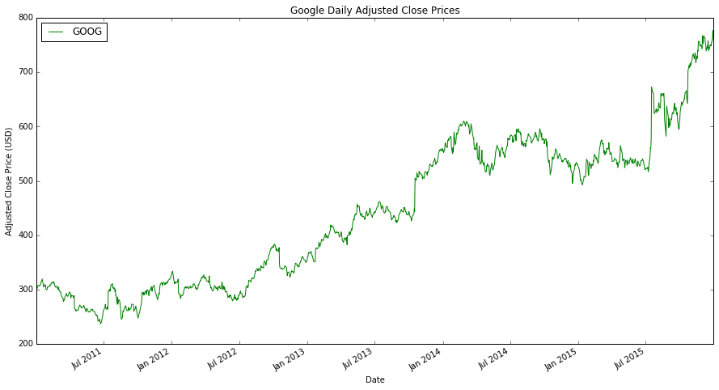

```python
google_prices = ts5.prices_to_plot
fig, ax = plt.subplots( nrows=1, ncols=1 )
fig.set_size_inches(15, 8)
google_prices.plot(ax = ax, title = "Google Daily Adjusted Close Prices", color="green")
ax.set_xlabel("Date")
ax.set_ylabel("Adjusted Close Price (USD)")
fig.savefig("{}.png".format("google"), bbox_inches="tight")
```

**When the prediction interval is 5 trading days**, the first 5 lines of the training data set is shown as follows. The first 18 columns are the technical indicators that will be used as the features in regression models. The column "Y" is the rate of change that will be used as the target value in the regression models. The last two column of the dataframe are the actual price and actual predicted price respectively. They are for testing use.

```python
ts5.df_train.head()
```

| Date | BB_5 | BB_10 | BB_20 | BB_5_SPY | BB_10_SPY | BB_20_SPY | ROC_5 | ROC_10 | ROC_20 | ROC_5_SPY | ... | ROC_20_SPY | RSI_5 | RSI_10 | RSI_20 | RSI_5_SPY | RSI_10_SPY | RSI_20_SPY | Y | price | future_price |
| --- | --- | --- | --- | --- | --- | --- | --- | --- | --- | --- | --- | --- | --- | --- | --- | --- | --- | --- | --- | --- | --- |
| 2011-02-01 | 0.118125 | -0.183153 | -0.244379 | 0.585810 | 0.932829 | 1.072472 | -0.014308 | -0.044698 | 0.011070 | 0.012155 | ... | 0.029044 | 35.605390 | 29.036532 | 52.966750 | 62.847810 | 57.060179 | 64.203219 | 0.012012 | 305.215316 | 308.881641 |
| 2011-02-02 | 0.259904 | -0.045392 | -0.232173 | 0.376137 | 0.634168 | 0.846668 | -0.007299 | -0.031262 | 0.016409 | 0.006324 | ... | 0.027642 | 42.066377 | 33.882845 | 54.431302 | 56.996637 | 64.698180 | 63.325730 | 0.007353 | 305.694840 | 307.942576 |
| 2011-02-03 | 0.282809 | -0.072445 | -0.336949 | 0.392360 | 0.627110 | 0.850692 | -0.010765 | -0.026517 | 0.001773 | 0.006077 | ... | 0.024600 | 38.903722 | 35.706894 | 50.507596 | 56.775243 | 67.441834 | 62.265606 | 0.010309 | 304.770739 | 307.912617 |
| 2011-02-04 | 0.215050 | -0.000001 | -0.283076 | 0.402007 | 0.644335 | 0.880355 | 0.016623 | -0.001389 | -0.004108 | 0.026856 | ... | 0.029516 | 83.411261 | 49.034710 | 48.774067 | 93.638686 | 67.774915 | 64.551050 | 0.022128 | 305.185327 | 311.938600 |
| 2011-02-07 | 0.815291 | 0.233651 | -0.097964 | 0.816678 | 0.766473 | 1.038023 | 0.023203 | 0.005253 | -0.003488 | 0.025567 | ... | 0.037990 | 89.506318 | 53.444921 | 48.957831 | 93.403731 | 68.141557 | 67.902132 | 0.022563 | 306.838691 | 313.761772 |

5 rows × 21 columns

In the training phase, the training set if firstly divided into a smaller training set (first 75%) and a validation set (25%). Then 4 methods with different tuning parameter's choices are attempted on the smaller training set, and evaluated on validation set in terms of MAPE. The information of the optimal tuning paramters of each method and the corresponding MAPE on validation set is shown as follows.

```python
ts5.best_learner.models_info
```

```
({'k': 19, 'mape_knn': 0.02545696712485012, 'method': 'KNN'},
 {'mape_bag': 0.02566753051931231, 'method': 'Bagging', 'n_bag': 100},
 {'mape_tree': 0.03240309360522801, 'method': 'Tree', 'min_sample_split': 30},
 {'mape_forest': 0.024768481500241548, 'method': 'RF', 'n_trees': 100})
```

From the above result, we can see that the method Random Forest performs best on validation test when the size of the Random Forest is 100. We will use the whole training data to fit a Random Forest model of size 100 as our final model. So, the final regression model at prediction interval of 5 is the Random Forest of size 100 built on the whole training data set. The information of the final regression model at prediction interval of 5 and its corresponding MAPE on validation set can be obtained as follows.

```python
ts5.best_learner.best
```

```
{'mape on validation': 0.024768481500241548, 'model': 'forest', 'n_trees': 100}
```

Similary, **When the prediction interval is 10 trading days**, the information of the optimal tuning paramters of each of the 4 methods and the corresponding MAPE on validation set is shown as follows.

```python
ts10.best_learner.models_info
```

```
({'k': 19, 'mape_knn': 0.03594874462557747, 'method': 'KNN'},
 {'mape_bag': 0.03635520324387722, 'method': 'Bagging', 'n_bag': 90},
 {'mape_tree': 0.04524077897382802, 'method': 'Tree', 'min_sample_split': 25},
 {'mape_forest': 0.036348421554841526, 'method': 'RF', 'n_trees': 80})
```

From the above result, we can see that the method KNN performs best on validation test when the k is 19. We will use the whole training data to fit a KNN model where k is 19 as our final model. So, the final regression model at prediction interval of 10 is the KNN model (k=19) built on the whole training data set. The information of the final regression model at prediction interval of 10 and its corresponding MAPE on validation set can be obtained as follows.

```python
ts10.best_learner.best
```

```
{'k': 19, 'mape on validation': 0.03594874462557747, 'model': 'knn'}
```

According to the result shown above, when the prediction interval is 10 trading days, the best regression model is KNN model where k is 19. The corresponding MAPE on validation set is 0.0360.

**When the prediction interval is 20 trading days**, the information of the optimal tuning paramters of each of the 4 methods and the corresponding MAPE on validation set is shown as follows.

```python
ts20.best_learner.models_info
```

```
({'k': 19, 'mape_knn': 0.05252033156784189, 'method': 'KNN'},
 {'mape_bag': 0.05274908788639233, 'method': 'Bagging', 'n_bag': 90},
 {'mape_tree': 0.07231547246541471, 'method': 'Tree', 'min_sample_split': 30},
 {'mape_forest': 0.05545045937819699, 'method': 'RF', 'n_trees': 100})
```

As a result, we can see that the method KNN performs best on validation test when the k is 19 at the prediction interval of 20. We will use the whole training data to fit a KNN model where k is 19 as our final model. So, the final regression model at prediction interval of 20 is the KNN model (k=19) built on the whole training data set. The information of the final regression model at prediction interval of 20 and its corresponding MAPE on validation set can be obtained as follows.

```python
ts20.best_learner.best
```

```
{'k': 19, 'mape on validation': 0.05252033156784189, 'model': 'knn'}
```

According to the result shown above, when the prediction interval is 20 trading days, the best regression model is KNN model that k is 19. The corresponding MAPE on validation set is 0.0525.

Now, we can see that the choice of **5 trading days** as the prediction interval results in the minimum MAPE on validation set among all the 3 choices of the prediction interval. So, we will use **5 trading days** as the prediction interval to build trading strategy and conduct testing study on testing date set. The results on testing data set in obtained as follows.

```
MAPE on the testing data set: 0.0297052784656

Sharpe Ratio of Portfolio Values: 1.63881468517
Sharpe Ratio of GOOG Stock Prices: 1.39511648707

Cumulative Return of Portfolio Values: 1.408431757
Cumulative Return of GOOG Stock Prices: 0.446002417656

Standard Deviation of Portfolio Values: 0.0426076341859
Standard Deviation of GOOG Stock Prices: 0.0186304892172

Average Daily Return of Portfolio Values: 0.00439862559468
Average Daily Return of GOOG Stock Prices: 0.001637323367
```

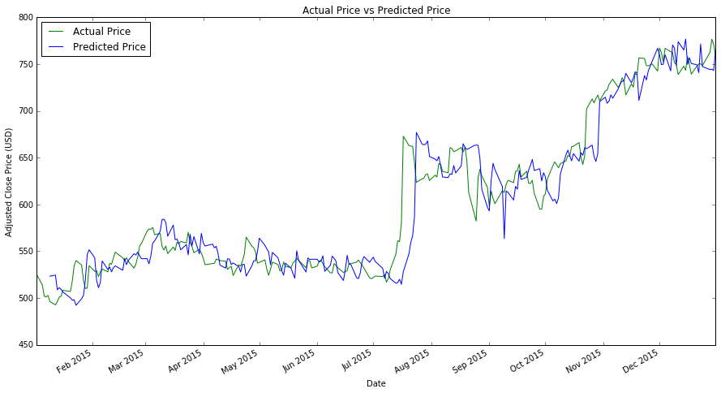

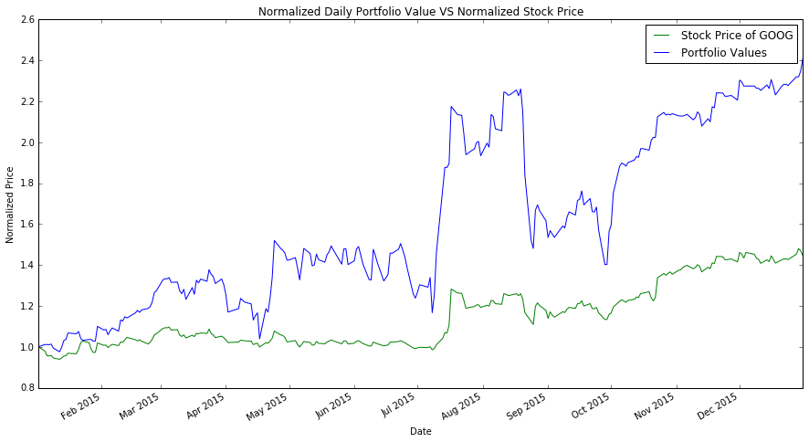

```python
ts5.create_results()
```

### 2.2 Case Study 2: APPLE

In this study, we will investigate the performance of our regression models and trading strategy on **Apple** stock price in the same way as in case study of Google.

Training date range: **01/01/2003**-**12/31/2007**  
Testing date range: **01/01/2008**-**12/31/2008**  
Attempts of Prediction Interval: **5**, **10** and **20** trading days respectively.

For each choice of prediction interval, we compute and return the MAPE of the final regression model on validation set in the training phase (done by the method **get_best_learner()** in **BestLearner** class). The prediction interval corresponds to the minimum MAPE will be used in the testing study. Firstly, the predictions will be made on testing date range, and will be compared with the actual price in terms of MAPE and plot. Secondly, a trading strategy is made based on the predictions. We will used this trading strategy to trade Apple stock during the testing date range. Thirdly, according to the orders we make by the trading strategy, the portfolio values of the days during the testing date range are computed. And we compute the cumulative return, daily returns and sharpe ratio of the portfolio values. Finally, we use the Apple stock price during the testing date range as the benchmark. The cumulative return, daily returns and sharpe ratio of the Apple stock prices are computed to compare with those of portfolio values, and to evaluate if our trading strategy built based on regression model can beat the Apple stock market.

First of all, we iinitialize the date ranges, stock symbol, prediction intervals and the objects of **TradeStock** class.

```python
# Apple stock study

#set training date range: 01/01/2003-12/31/2007
train_sd = dt.datetime(2003,1,1)
train_ed = dt.datetime(2007,12,31)

#set testing date range: 01/01/2008-12/31/2008
test_sd = dt.datetime(2008,1,1)
test_ed = dt.datetime(2008,12,31)

#symbol of Apple stock: AAPL
symbol = "AAPL"

#set prediction interval: 5, 10 and 20 trading days respectively
n_days_5 = 5
n_days_10 = 10
n_days_20 = 20

#initialize the object of TradeStock() class for each prediction interval
ts5 = TradeStock(symbol, train_sd, train_ed, test_sd, test_ed, n_days_5)
ts10 = TradeStock(symbol, train_sd, train_ed, test_sd, test_ed, n_days_10)
ts20 = TradeStock(symbol, train_sd, train_ed, test_sd, test_ed, n_days_20)
```

We can visualize the Apple Adjusted Close price during the date range of training and testing by the following code.

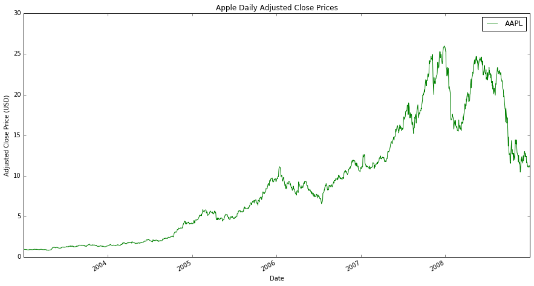

```python
apple_prices = ts5.prices_to_plot
fig, ax = plt.subplots( nrows=1, ncols=1 )
fig.set_size_inches(15, 8)
apple_prices.plot(ax = ax, title = "Apple Daily Adjusted Close Prices", color="green")
ax.set_xlabel("Date")
ax.set_ylabel("Adjusted Close Price (USD)")
fig.savefig("{}.png".format("apple"), bbox_inches="tight")
```

From the above plot, we can see the trend of Apple stock price from 01/01/2003 to 12/31/2008. We will use the price data from 01/01/2003 to 12/31/2007 to generate technical indicators and corresponding rate of change as training data set to train our stock price predictor that is used for testing over the date range from 01/01/2008 to 12/31/2008.

**When the prediction interval is 5 trading days**, the first 5 lines of the training data set is shown as follows. The first 18 columns are the technical indicators that will be used as the features in regression models. The column "Y" is the rate of change that will be used as the target value in the regression models. The last two column of the dataframe are the actual price and actual predicted price respectively. They are for testing use.

```python
ts5.df_train.head()
```

| Date | BB_5 | BB_10 | BB_20 | BB_5_SPY | BB_10_SPY | BB_20_SPY | ROC_5 | ROC_10 | ROC_20 | ROC_5_SPY | ... | ROC_20_SPY | RSI_5 | RSI_10 | RSI_20 | RSI_5_SPY | RSI_10_SPY | RSI_20_SPY | Y | price | future_price |
| --- | --- | --- | --- | --- | --- | --- | --- | --- | --- | --- | --- | --- | --- | --- | --- | --- | --- | --- | --- | --- | --- |
| 2003-01-31 | -0.170116 | 0.194620 | -0.142438 | 0.287061 | -0.266607 | -0.601093 | 0.040580 | -0.017783 | -0.029729 | -0.003705 | ... | -0.055013 | 65.730347 | 45.912099 | 44.859870 | 47.394148 | 26.827392 | 37.238923 | -0.014624 | 0.934271 | 0.920608 |
| 2003-02-03 | 0.182056 | 0.522892 | 0.317534 | 0.263333 | -0.143174 | -0.520141 | 0.037509 | 0.039716 | -0.016107 | 0.012089 | ... | -0.056048 | 65.142812 | 59.459544 | 47.321490 | 60.039028 | 31.019739 | 36.885269 | -0.021146 | 0.953789 | 0.933620 |
| 2003-02-04 | 0.052510 | 0.359070 | 0.262126 | -0.203249 | -0.349205 | -0.589277 | 0.001372 | 0.041369 | -0.020134 | -0.005243 | ... | -0.081540 | 50.735169 | 59.863967 | 46.696031 | 45.794355 | 32.583280 | 29.797464 | -0.017123 | 0.949885 | 0.933620 |
| 2003-02-05 | -0.094565 | 0.078309 | 0.062271 | -0.350931 | -0.467025 | -0.605788 | -0.032150 | 0.041066 | -0.026936 | -0.018848 | ... | -0.084978 | 29.310596 | 59.660915 | 45.689649 | 34.416813 | 34.280335 | 29.328455 | -0.004152 | 0.940126 | 0.936223 |
| 2003-02-06 | -0.279777 | 0.006477 | 0.039551 | -0.618472 | -0.692903 | -0.599777 | 0.007682 | 0.018349 | -0.008247 | 0.000237 | ... | -0.075938 | 59.649454 | 54.850828 | 48.623886 | 50.279275 | 29.558568 | 30.849910 | 0.007623 | 0.938825 | 0.945982 |

5 rows × 21 columns

In the training phase, the training set if firstly divided into a smaller training set (first 75%) and a validation set (25%). Then 4 methods with different tuning parameter's choices are attempted on the smaller training set, and evaluated on validation set in terms of MAPE. The information of the optimal tuning paramters of each method and the corresponding MAPE on validation set is shown as follows.

```python
ts5.best_learner.models_info
```

```
({'k': 19, 'mape_knn': 0.04061910194737031, 'method': 'KNN'},
 {'mape_bag': 0.040373157178335416, 'method': 'Bagging', 'n_bag': 50},
 {'mape_tree': 0.04960066179964768, 'method': 'Tree', 'min_sample_split': 25},
 {'mape_forest': 0.0405681128102316, 'method': 'RF', 'n_trees': 80})
```

From the above result, we can see that the method Bagging performs best on validation test when the ensemble size is 50 and each base KNN model in it uses k as 19. We will use the whole training data to fit a Bagging model where the ensemble size of 50 and the k of each base KNN model is 19. So, the final regression model at prediction interval of 5 is the Bagging model built on the whole training data set. The information of the final regression model at prediction interval of 5 and its corresponding MAPE on validation set can be obtained as follows.

```python
ts5.best_learner.best
```

```
{'k': 19,
 'mape on validation': 0.040373157178335416,
 'model': 'bag',
 'n_learners': 50}
```

According to the result shown above, when the prediction interval is 5 trading days, the best regression model is Bagging. The size of the Bagging model is 50. The base KNN model uses 19 as the choice of k. The corresponding MAPE on validation set is 0.0404.

Similary, **When the prediction interval is 10 trading days**, the information of the optimal tuning paramters of each of the 4 methods and the corresponding MAPE on validation set is shown as follows.

```python
ts10.best_learner.models_info
```

```
({'k': 19, 'mape_knn': 0.05653288781663523, 'method': 'KNN'},
 {'mape_bag': 0.05637820927163121, 'method': 'Bagging', 'n_bag': 30},
 {'mape_tree': 0.06576429306561064, 'method': 'Tree', 'min_sample_split': 25},
 {'mape_forest': 0.0566956067165738, 'method': 'RF', 'n_trees': 100})
```

From the above result, we can see that the method Bagging performs best on validation test when the ensemble size is 30 and the k of each KNN base model is 19. We will use the whole training data to fit a Bagging model as our final model in this case study using 30 as the ensemble size and 19 as the k of each KNN base model. The information of the final regression model at prediction interval of 10 and its corresponding MAPE on validation set can be obtained as follows.

```python
ts10.best_learner.best
```

```
{'k': 19,
 'mape on validation': 0.05637820927163121,
 'model': 'bag',
 'n_learners': 30}
```

According to the result shown above, when the prediction interval is 10 trading days, the best regression model is Bagging model where the size is 30. Also, the k of each KNN base model in the bag is 19. The corresponding MAPE on validation set is 0.0564.

**When the prediction interval is 20 trading days**, the information of the optimal tuning paramters of each of the 4 methods and the corresponding MAPE on validation set is shown as follows.

```python
ts20.best_learner.models_info
```

```
({'k': 18, 'mape_knn': 0.0917775224782312, 'method': 'KNN'},
 {'mape_bag': 0.09122284133398262, 'method': 'Bagging', 'n_bag': 80},
 {'mape_tree': 0.10314242935808529, 'method': 'Tree', 'min_sample_split': 30},
 {'mape_forest': 0.09367191113048916, 'method': 'RF', 'n_trees': 50})
```

As a result, we can see that the method Bagging performs best on validation test when the ensemble size is 80 and the k of each KNN base model is 18 at the prediction interval of 20. We will use the whole training data to fit a Bagging model as our final model in this case study using 80 as the ensemble size and 18 as the k of each KNN base model. The information of the final regression model at prediction interval of 20 and its corresponding MAPE on validation set can be obtained as follows.

```python
ts20.best_learner.best
```

```
{'k': 18,
 'mape on validation': 0.09122284133398262,
 'model': 'bag',
 'n_learners': 80}
```

According to the result shown above, when the prediction interval is 20 trading days, the best regression model is Bagging model where the size is 80 and the k of each KNN base model is 18. The corresponding MAPE on validation set is 0.0912.

Now, we can see that the **choice of 5 trading days** as the prediction interval results in the minimum MAPE on validation set among all the 3 choices of the prediction interval. So, we will use 5 trading days as the prediction interval to build trading strategy and conduct testing study on testing date set. The results on testing data set in obtained as follows.

```
MAPE on the testing data set: 0.0690236869844

Sharpe Ratio of Portfolio Values: -1.69311492857
Sharpe Ratio of AAPL Stock Prices: -1.12005215783

Cumulative Return of Portfolio Values: -0.155480618
Cumulative Return of AAPL Stock Prices: -0.561948259261

Standard Deviation of Portfolio Values: 0.00610999153946
Standard Deviation of AAPL Stock Prices: 0.0367283195157

Average Daily Return of Portfolio Values: -0.000651668573035
Average Daily Return of AAPL Stock Prices: -0.00259142732948
```

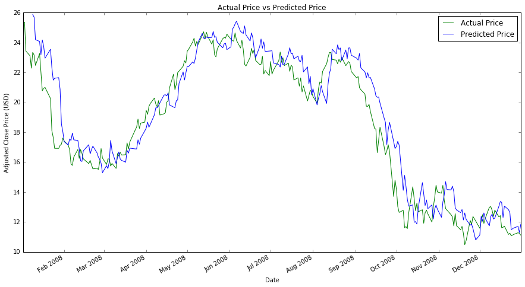

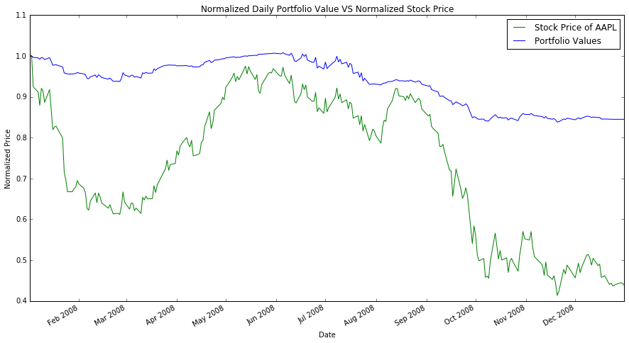

```python
ts5.create_results()
```

The above results has shown that when the prediction interval is 5 trading days, the MAPE on test set is 0.0690. The difference between the actual and predicted stock price can be visualized in the first plot.

Also, our trading strategy beats the stock price in terms of both cumulative return. Having the start value of 100000 USD at the begining of year 2008, if we use our trading strategy to trade Apple stock, we can lose about 15.6% of total value at the end of the year 2008. However, if we don't use any trading strategy, and just buy Apple stock using all the 100000 USD at the beggining of year 2008, and hold the shares all year, we would lose about 56.2% of total value at the end of the year 2008. From the second plot, we can see that our normalized portfolio value is bigger than the normalized stock price at any day in the testing date range. In another word, our trading strategy not only beats the market at the end of the year 2008, but also beats the market through the year 2008.

### 2.3 Case Study 3: IBM

In this study, we will investigate the performance of our regression models and trading strategy on **IBM** stock price in the same way as in case study of Google.

Training date range: **01/01/2010**-**12/31/2013**  
Testing date range: **01/01/2014**-**12/31/2014**  
Attempts of Prediction Interval: **5**, **10** and **20** trading days respectively.

For each choice of prediction interval, we compute and return the MAPE of the final regression model on validation set in the training phase (done by the method **get_best_learner()** in **BestLearner** class). The prediction interval corresponds to the minimum MAPE will be used in the testing study. Firstly, the predictions will be made on testing date range, and will be compared with the actual price in terms of MAPE and plot. Secondly, a trading strategy is made based on the predictions. We will used this trading strategy to trade IBM stock during the testing date range. Thirdly, according to the orders we make by the trading strategy, the portfolio values of the days during the testing date range are computed. And we compute the cumulative return, daily returns and sharpe ratio of the portfolio values. Finally, we use the IBM stock price during the testing date range as the benchmark. The cumulative return, daily returns and sharpe ratio of the IBM stock prices are computed to compare with those of portfolio values, and to evaluate if our trading strategy built based on regression model can beat the IBM stock market.

First of all, we iinitialize the date ranges, stock symbol, prediction intervals and the objects of **TradeStock** class.

```python
# IBM stock study

#set training date range: 01/01/2010-12/31/2013
train_sd = dt.datetime(2010,1,1)
train_ed = dt.datetime(2013,12,31)

#set testing date range: 01/01/2014-12/31/2014
test_sd = dt.datetime(2014,1,1)
test_ed = dt.datetime(2014,12,31)

#symbol of IBM stock: IBM
symbol = "IBM"

#set prediction interval: 5, 10 and 20 trading days respectively
n_days_5 = 5
n_days_10 = 10
n_days_20 = 20

#initialize the object of TradeStock() class for each prediction interval
ts5 = TradeStock(symbol, train_sd, train_ed, test_sd, test_ed, n_days_5)
ts10 = TradeStock(symbol, train_sd, train_ed, test_sd, test_ed, n_days_10)
ts20 = TradeStock(symbol, train_sd, train_ed, test_sd, test_ed, n_days_20)
```

We can visualize the IBM Adjusted Close price during the date range of training and testing by the following code.

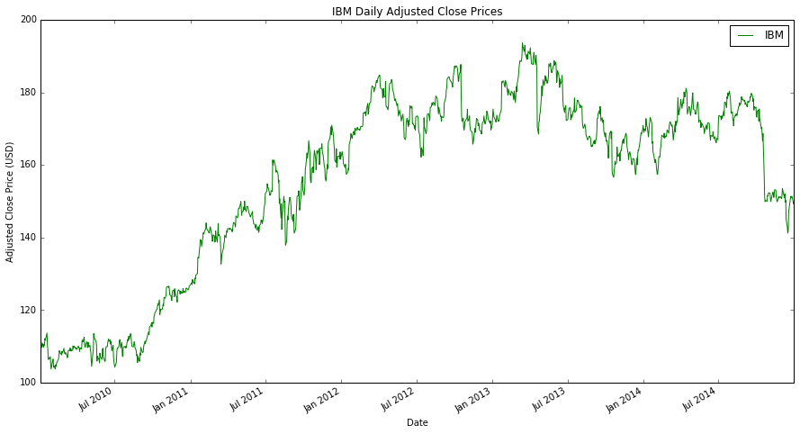

```python
ibm_prices = ts5.prices_to_plot
fig, ax = plt.subplots( nrows=1, ncols=1 )
fig.set_size_inches(15, 8)
ibm_prices.plot(ax = ax, title = "IBM Daily Adjusted Close Prices", color="green")
ax.set_xlabel("Date")
ax.set_ylabel("Adjusted Close Price (USD)")
fig.savefig("{}.png".format("ibm"), bbox_inches="tight")
```

**When the prediction interval is 5 trading days**, the first 5 lines of the training data set is shown as follows. The first 18 columns are the technical indicators that will be used as the features in regression models. The column "Y" is the rate of change that will be used as the target value in the regression models. The last two column of the dataframe are the actual price and actual predicted price respectively. They are for testing use.

```python
ts5.df_train.head()
```

| Date | BB_5 | BB_10 | BB_20 | BB_5_SPY | BB_10_SPY | BB_20_SPY | ROC_5 | ROC_10 | ROC_20 | ROC_5_SPY | ... | ROC_20_SPY | RSI_5 | RSI_10 | RSI_20 | RSI_5_SPY | RSI_10_SPY | RSI_20_SPY | Y | price | future_price |
| --- | --- | --- | --- | --- | --- | --- | --- | --- | --- | --- | --- | --- | --- | --- | --- | --- | --- | --- | --- | --- | --- |
| 2010-02-02 | 0.324041 | -0.086810 | -0.457945 | 0.576021 | 0.130614 | -0.330966 | -0.001750 | -0.064187 | -0.052246 | 0.009789 | ... | -0.026030 | 48.563956 | 25.101218 | 38.126294 | 58.991585 | 31.747267 | 42.345600 | -0.014092 | 106.419374 | 104.919744 |
| 2010-02-03 | 0.463186 | 0.055026 | -0.396159 | 0.338533 | 0.143535 | -0.397377 | -0.005304 | -0.035240 | -0.039664 | 0.000000 | ... | -0.033442 | 45.353692 | 33.037718 | 40.621616 | 50.000000 | 33.360661 | 40.266403 | -0.018309 | 106.529587 | 104.579122 |
| 2010-02-04 | -0.420778 | -0.682993 | -0.719507 | -0.656680 | -1.042541 | -0.898042 | -0.006061 | -0.046512 | -0.053846 | -0.019619 | ... | -0.063935 | 44.855968 | 29.919696 | 38.127552 | 36.868069 | 30.373148 | 34.077972 | 0.010434 | 104.274541 | 105.362555 |
| 2010-02-05 | -0.402445 | -0.408426 | -0.578931 | -0.498481 | -0.729344 | -0.759179 | 0.009233 | -0.015777 | -0.046546 | -0.006798 | ... | -0.065943 | 58.759662 | 41.722400 | 39.796951 | 44.895129 | 38.544494 | 33.318561 | 0.008376 | 104.715374 | 105.592471 |
| 2010-02-08 | -0.539895 | -0.637933 | -0.659430 | -0.465255 | -0.757644 | -0.787100 | -0.018007 | -0.029297 | -0.064386 | -0.029067 | ... | -0.075762 | 28.680622 | 35.143070 | 35.645054 | 24.640005 | 32.892435 | 31.097561 | 0.027486 | 103.787178 | 106.639883 |

5 rows × 21 columns

In the training phase, the training set if firstly divided into a smaller training set (first 75%) and a validation set (25%). Then 4 methods with different tuning parameter's choices are attempted on the smaller training set, and evaluated on validation set in terms of MAPE. The information of the optimal tuning paramters of each method and the corresponding MAPE on validation set is shown as follows.

```python
ts5.best_learner.models_info
```

```
({'k': 19, 'mape_knn': 0.021452646937655705, 'method': 'KNN'},
 {'mape_bag': 0.021371895475154407, 'method': 'Bagging', 'n_bag': 70},
 {'mape_tree': 0.02523233999056726, 'method': 'Tree', 'min_sample_split': 30},
 {'mape_forest': 0.021782975620517158, 'method': 'RF', 'n_trees': 100})
```

From the above result, we can see that the method Bagging performs best on validation test when the ensemble size is 70 and each base KNN model in it uses k as 19. We will use the whole training data to fit a Bagging model where the ensemble size of 70 and the k of each base KNN model is 19. So, the final regression model at prediction interval of 5 is the Bagging model built on the whole training data set. The information of the final regression model at prediction interval of 5 and its corresponding MAPE on validation set can be obtained as follows.

```python
ts5.best_learner.best
```

```
{'k': 19,
 'mape on validation': 0.021371895475154407,
 'model': 'bag',
 'n_learners': 70}
```

According to the result shown above, when the prediction interval is 5 trading days, the best regression model is Bagging. The size of the Bagging model is 70. The base KNN model uses 19 as the choice of k. The corresponding MAPE on validation set is 0.0214.

Similary, **When the prediction interval is 10 trading days**, the information of the optimal tuning paramters of each of the 4 methods and the corresponding MAPE on validation set is shown as follows.

```python
ts10.best_learner.models_info
```

```
({'k': 19, 'mape_knn': 0.032006890202359105, 'method': 'KNN'},
 {'mape_bag': 0.032071173398103094, 'method': 'Bagging', 'n_bag': 90},
 {'mape_tree': 0.03526866017826384, 'method': 'Tree', 'min_sample_split': 30},
 {'mape_forest': 0.03211060970959972, 'method': 'RF', 'n_trees': 50})
```

From the above result, we can see that the method KNN performs best on validation test when the k of KNN model is 19. We will use the whole training data to fit a KNN model as our final model in this case study using 19 as the k of the KNN model. The information of the final regression model at prediction interval of 10 and its corresponding MAPE on validation set can be obtained as follows.

```python
ts10.best_learner.best
```

```
{'k': 19, 'mape on validation': 0.032006890202359105, 'model': 'knn'}
```

**When the prediction interval is 20 trading days**, the information of the optimal tuning paramters of each of the 4 methods and the corresponding MAPE on validation set is shown as follows.

```python
ts20.best_learner.models_info
```

```
({'k': 19, 'mape_knn': 0.043618416500901466, 'method': 'KNN'},
 {'mape_bag': 0.043484615218802994, 'method': 'Bagging', 'n_bag': 70},
 {'mape_tree': 0.05222688436395489, 'method': 'Tree', 'min_sample_split': 25},
 {'mape_forest': 0.044236885316628, 'method': 'RF', 'n_trees': 100})
```

As a result, we can see that the method Bagging performs best on validation test when the ensemble size is 70 and the k of each KNN base model is 19 at the prediction interval of 20. We will use the whole training data to fit a Bagging model as our final model in this case study using 70 as the ensemble size and 19 as the k of each KNN base model. The information of the final regression model at prediction interval of 20 and its corresponding MAPE on validation set can be obtained as follows.

```python
ts20.best_learner.best
```

```
{'k': 19,
 'mape on validation': 0.043484615218802994,
 'model': 'bag',
 'n_learners': 70}
```

According to the result shown above, when the prediction interval is 20 trading days, the best regression model is Bagging model where the size is 70 and the k of each KNN base model is 19. The corresponding MAPE on validation set is 0.0435.

Now, we can see that the **choice of 5 trading days** as the prediction interval results in the minimum MAPE on validation set among all the 3 choices of the prediction interval. So, we will use 5 trading days as the prediction interval to build trading strategy and conduct testing study on testing date set. The results on testing data set in obtained as follows.

```
MAPE on the testing data set: 0.0200172444308

Sharpe Ratio of Portfolio Values: 0.461894182491
Sharpe Ratio of IBM Stock Prices: -0.622901374197

Cumulative Return of Portfolio Values: 0.101729948
Cumulative Return of IBM Stock Prices: -0.114237611705

Standard Deviation of Portfolio Values: 0.0207210745365
Standard Deviation of IBM Stock Prices: 0.0108156810659

Average Daily Return of Portfolio Values: 0.000602912787213
Average Daily Return of IBM Stock Prices: -0.000424397572228
```

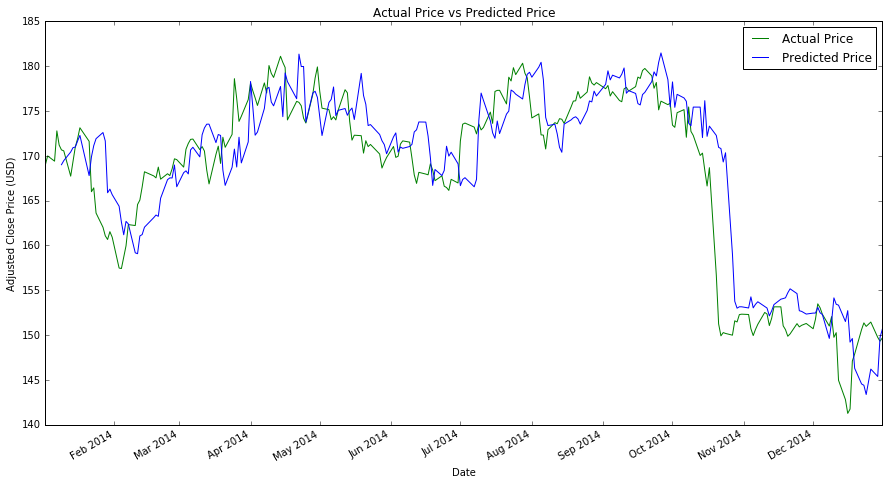

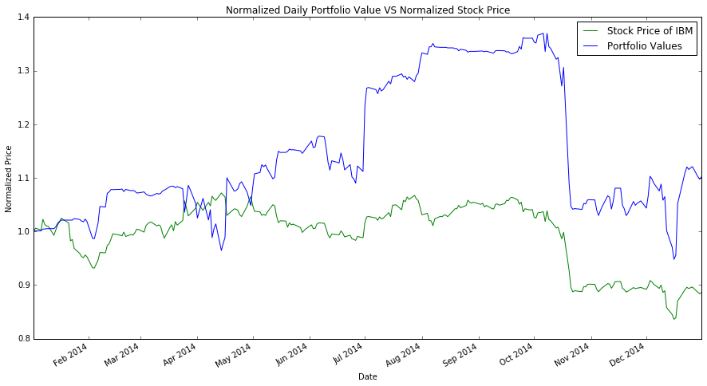

```python
ts5.create_results()
```

The above results has shown that when the prediction interval is 5 trading days, the MAPE on test set is 0.0200. The difference between the actual and predicted stock price can be visualized in the first plot.

### 2.4 Conclusion

In summary, we have shown that our stock price predictor and corresponding trading strategy have consistently good performances on different testing sets.